# Matching data references and institutional output to map the reuse of biomedical research data

Authors

Affiliation

Avihay Cohen

Berlin Institute of Health at Charité - Universitätsmedizin Berlin (BIH), QUEST Center for Responsible Research

Blanka Ivanović

Berlin Institute of Health at Charité - Universitätsmedizin Berlin (BIH), QUEST Center for Responsible Research

Anastasiia Iarkaeva

Berlin Institute of Health at Charité - Universitätsmedizin Berlin (BIH), QUEST Center for Responsible Research

Vladislav Nachev

Berlin Institute of Health at Charité - Universitätsmedizin Berlin (BIH), QUEST Center for Responsible Research

Evgeny Bobrov

Berlin Institute of Health at Charité - Universitätsmedizin Berlin (BIH), QUEST Center for Responsible Research

# Abstract

Data sharing is increasingly expected by funders, journals, institutions, and other actors in the research system. This expectation is based primarily on the assumption that some of the shared data will be reused. Reuse can take many forms and have many purposes, but currently the only way to detect reuse of data at scale is to screen the research literature. We used the Data Citation Corpus to detect instances in which datasets shared by researchers from our biomedical research institution had been referenced, which we interpreted as indicative of reuse. We observed that 4.9% of datasets identified through articles published between 2020 and 2023 had been referenced by February 1<sup>st</sup>, 2025. Overall, 175 Charité datasets from this period were reused, which had been referenced 1,497 times. The large majority of reused datasets were from ‘omics’ fields, which generate particularly structured and standardized data. Data from humans had a higher probability of reuse, as well as COVID-19-related data. Dataset properties indicative of technical reusability, such as DOIs and Creative Commons licenses, had no positive influence on reuse probability, presumably because these are not used by the most common omics repositories. We conducted a complementary analysis of datasets shared alongside data articles. Here, we observed that a major fraction of references to data articles were in fact referring to shared datasets. Based on a sample, we extrapolated that indirect data citations account for an additional approximately 846 reuse cases. Unlike data references, indirect data citations often referred to datasets in disciplinary repositories from fields outside of omics, as well as general-purpose repositories. Our study shows that data are reused on a large scale, but at the same time reuse of data in many fields is limited, especially if data are deposited in general-purpose repositories. Data are reused most if it is shared with disciplinary metadata and/or described by data articles. Our methods do not allow us to map data reuse in its entirety, and further large-scale studies on the determinants, temporal patterns and purposes of data reuse are needed.

# 1 Introduction

## 1.1 The relevance of investigating dataset reuse

A lot of effort is invested into the sharing of data by researchers by creating infrastructures, developing know-how, and raising awareness. The practice of data sharing is called upon, supported, and sometimes required by funders (Wellcome, n.d.), journals (Loder et al. 2024; PLOS Medicine, n.d.), institutions (The Neuro, n.d.), scientific societies (Schönbrodt, Gollwitzer, and Abele-Brehm 2017), and governments (“UNESCO Recommendation on Open Science,” n.d.). Data sharing serves multiple purposes (Gregory et al. 2020; Locher et al. 2023). The availability of data has a positive effect on trust (Rosman et al. 2022), and thus availability of data is a value in itself. However, we see a wide agreement that value is primarily created by data sharing when somebody else takes this data and uses it in some way. To quantify the impact of shared data, we thus focused on its reuse, and, more specifically, on references to dataset reuse in the published literature. Reuse can take place in a lot of ways, and by many actors: in addition to researchers, it could also be by governments, civil society, companies, or other actors. In addition, researchers might reuse data for purposes outside of research, such as teaching (Gregory et al. 2020). Thus, many reuse cases might never find their way into the literature. However, the traces of data reuse in the literature are currently the only way to investigate at scale, whether data are reused. Thus, we focus on references to data reuse in the published literature as a proxy of overall data reuse to investigate the impact of shared data. Ultimately, answering questions around data reuse is central to advance and focus efforts regarding data sharing in the future (EOSC EDEN, n.d.).

## 1.2 Terminology

We are aware that data reuse is in itself not a self-evident concept, and it has even been argued that it cannot be defined at all (Sandt et al. 2019). Although we argue that defining data reuse as a distinct practice is both intuitive and useful, a line is certainly very difficult to draw. For the purpose of our analysis, we consider every instance where the article reporting data reuse (‘reusing article’) and the article reporting data sharing (‘sharing article’) do not have author overlap. Although this is certainly a simplification, it seems justified and our own analyses show that typically authors see this distinction the way we do, e.g. in that references to what we define as ‘data reuse’ are much more often found outside of data availability statements (DAS) than references to what we define as ‘own data’. However, this issue warrants its own discussion, and probably a simple dichotomy might not suffice in the long term.

We furthermore only consider reuse of data shared in repositories. Data reuse can also take place within groups, departments, consortia, or in other arrangements, without publication of the data. Based on qualitative sociological research, Barlösius (2023) describes open sharing as only one of three sharing types. This is complemented by “closed communal sharing, based on a feeling of belonging together” and “closed associative sharing, in which the participants act on the basis of an agreement”. A framework for data reuse which describes the effort needed to reuse data as “data distance” and lists different dimensions which influence this distance is provided by Borgman and Groth (2025)**.** “Communal sharing” is characterized by a short data distance and is thus potentially very effective, but cannot be assessed using bibliographic methods. While our analysis primarily builds on open sharing of data, it also includes restricted-access sharing via repositories, which could be seen as being an example of “associative sharing”. With regard to mapping data (re)use practices, one of the authors (EB) is involved in the FORCE11 Working Group “Data Usage Typologies” (FORCE11, n.d.), which aims to define types of data (re)use and their respective properties, encompassing any type of data use.

The literature on data use and reuse employs different terms for statements which refer to utilized datasets. We follow the terminology employed by Gregory et al. (2023). Thus, we use the term ‘data citation’ for data objects in reference lists, while the term ‘data mention’ is used for statements in the publication text. As a consequence, **the Data Citation Corpus analyzed here** is, in this terminology, a corpus of both ‘data mentions’ and ‘data citations’ and, **in a summarizing fashion, is denoted as a corpus of ‘data references’**. ‘Data citations’ and ‘data mentions’ are synonymous with ‘formal data citations’ and ‘informal data citations’, respectively, as used by Park, You, and Wolfram (2018). The third type of data references which we analyze are ‘indirect data citations’ (Sandt et al. 2019). In our case, this applies to cases where a data article rather than the dataset itself is referenced. Definitions of importance to this article are included in the glossary.

# Glossary

| Term | Definition |
| --- | --- |
| data article | Type of research article which presents a dataset’s background, methodology and sometimes possible applications, but no analysis of this dataset. Used synonymously with “data paper”. |
| data citation | Entry in a reference list or bibliography of a research article which refers to a data object. |
| data reuse | The use of a data object by researchers other than the data creators, as indicated by a →data mention in a research article. Please consult Section 4.5 “What is data reuse anyway” for details. |
| data mention | Statement in a research article full-text (including a data availability statement) which refers to a data object. |
| data reference | Summary term for →data citation and →data mention. |
| indirect data citation | Citation from a research article to a data article where the digital object used has been the dataset presented in the data article, rather than the text of the data article itself. |

## 1.3 Institutional dataset reuse as specific application

We were interested in the reuse of data published by researchers from our institution. The primary questions of our study are which datasets have been mentioned in the literature, and how often they were mentioned. In addition, we investigated the characteristics of reuse with regard to properties of data (e.g., whether it is data collected from human participants), properties of metadata (e.g., license), and the time lag between data publication and data reference. This study is, to our knowledge, the first to analyze dataset references in the published literature with focus on a research-performing institution.

We work at the Charité – Universitätsmedizin Berlin, a large university medical hospital, where very diverse biomedical research is undertaken. The Charité’s researchers published ca. 5,600 reviewed articles in 2023, of which 79% are open access in some form. The research ranges from clinical and epidemiological studies to preclinical studies in animals, cell cultures, and in silico. A smaller subset of publications also stems from views onto medicine from other domains, including sociological, historical, and meta-research approaches. Information on publication access types, as well as several other metrics of open and responsible research can be found in an institutional Responsible Research Dashboard (“Charité Metrics Dashboard: Charité Dashboard on Responsible Research,” n.d.).

The list of datasets published by our institution is an outcome of the process of locally monitoring open science practices. We have collected information on the publication of datasets by Charité’s researchers, and thus we know for the period 2020-2023 which datasets have been shared. This list can then be matched to references in the Data Citation Corpus to investigate the reuse of datasets from our institution. The process used to obtain a list of published datasets is briefly described in the methods section, which also provides references to detailed descriptions.

## 1.4 Data Citation Corpus as data source

The use of references to datasets is complicated by the fact that data reuse is rarely acknowledged by data citations (Ninkov et al. 2021; Gregory et al. 2023). More commonly, data reuse is mentioned in a more or less informal way in different article sections (Park, You, and Wolfram 2018; Sandt et al. 2019). The Data Citation Corpus (DCC) (DataCite 2024) is the first comprehensive approach to address this issue by text-mining a large body of the published literature for references to reused data. It includes 4,892,673 dataset references to 3,092,951 datasets in 1,837 repositories, mentioned in 1,879,482 research articles from 18,677 journals. These and further numbers are displayed in the DCC dashboard (“Dashboard Page - Data Citation Corpus,” n.d.) Beyond this dashboard, so far only two analyses making use of the DCC have been published to date (Hahnel, Smith, and Campbell 2024; Strecker, Soltau, and Bach 2025). Also, there is no comprehensive validation as yet with regard to the completeness, correctness, or bias within the DCC, although Page (2024) has documented common data quality issues in the DCC. Such a validation could e.g. investigate, whether known cases of data referencing are present in the DCC. However, the lack of large and diverse sets of data references which are in themselves validated precludes an extensive validation of the DCC at the time being.

The DCC contains, in addition to data mentions, also a small fraction of data citations. We did not find an explicit statement on this, but we deduce this from the observations that (i) the DCC includes records from DataCite Event Data (Make Data Count, n.d.), (ii) the DataCite Event Data service imports data citation events from the Crossref data citation endpoint (DataCite, n.d.), and (iii) Crossref’s endpoint scans the reference field and the relation field of article metadata (Crossref, n.d.), where the reference field represents bibliographic references. However, there is no field in the DCC which would disambiguate data citations and data references, and a record originating from DataCite Event Data cannot automatically be classified as a data citation, as the Event Data combines Crossref bibliographic references with other structured relationships which may have been created independently of the article’s printed reference list. Taken together, this precludes any sub-analyses of data citations vs. data references. For further limitations of the DCC, we refer to the respective section of the DCC documentation (Make Data Count, n.d.).

## 1.5 Indirect data citations via data articles

‘Data articles’ are a type of article which explains in detail the provenance and properties of a dataset, but does not report results derived from its analysis. Other terms are ‘data descriptor’ or ‘data paper’, and we understand these terms to be synonymous. In addition to data citations and data mentions, many authors reference not the reused dataset directly, but rather a data article, if such an article exists (Callaghan et al. 2012; Gregory et al. 2023; Yoon et al. 2019). Detecting the whole breadth of indirect data references would require investigating every single reference to articles by Charité authors to distinguish between indirect dataset references and references to the content of the research article proper. This can currently not be reliably automated and is not feasible manually, as it would apply to at least a high five-digit number of articles. We thus include in our analysis only citations to (but not mentions of) data articles. We set the focus on data articles because the probability of encountering indirect data citations is substantially higher for data articles than amongst citations to research articles generally. We have used data articles in two common data journals to track such indirect data citations. This complements the analysis of the DCC and allows for a more comprehensive picture of dataset reuse.

# 2 Methods

## 2.1 High-level overview of the process

The process of cleaning our own source dataset and matching it to entries in the DCC consists of the following steps, described in below sections in more detail:

1. Preparing and quality-checking the DCC for analysis (Section 2.2)
2. Preparing the Charité dataset identifier list for analysis (Section 2.3)
3. Matching Charité dataset identifiers with identifiers in the DCC; this way, we determined which publications have referenced datasets underlying publications by Charité authors

This description applies to the analysis of direct dataset references (See Figure 1). For the analysis of indirect data references through data articles, additional steps had to be performed, as described in Section 2.8 (See Figure 8 (a)). Code and data underlying all presented analyses have been published in Cohen et al. (2026).

## 2.2 Preparing and quality-checking the Data Citation Corpus

The DCC was downloaded as separate CSV files which were then combined into one table. We performed several steps on that table to standardize the DCC for our needs, as well as to quality-check the entries:

1. Searching for missing (NA and NULL) values in fields that are relevant for the analysis; no such cases were observed
2. Checking whether article publication years are plausible; we found six entries with implausible publication years (e.g., 2104, 2108) and corrected them by exchanging the positions of “1” and “0”; these corrected publication years were then manually verified
3. Renaming several columns for clarity
4. DOIs of datasets deposited in general-purpose repositories (i.e., Zenodo, Figshare, Dryad, OSF, Mendeley, Apollo and Harvard Dataverse) were found to appear in multiple formats within the DCC; to ensure consistency, these DOIs were standardized to a uniform format
5. Subsequently, excess characters were stripped from both the dataset and the article DOIs; this included leading and trailing slashes, dots and spaces, together with any other space found within the string value of the dataset or the article DOI; furthermore, commas were replaced with dots
6. Version information was removed from all dataset identifiers; this was done to detect all uses of a dataset, regardless of its version, based on the assumption that a new version of a dataset remains the same dataset
7. After the aforementioned cleaning steps, it could be observed that the DCC included 218,054 cases where the same DOI was listed in both the ‘referencing article’ and ‘referenced dataset’ fields; such cases were removed from the corpus
8. Lastly, to exclude preprints from analysis, all cases where the listed repository name contained the suffix “rxiv” (e.g., bioRxiv, medRxiv, arXiv) were removed; preprints were excluded primarily to avoid the consolidation step of removing those preprints which were later also published as peer-reviewed articles (i.e., “double-dipping”); this is all the more important, as peer-reviewed versions appear with a variable delay, and thus the set of preprints to include would be changing over time, increasing the complexity of updating or re-analyzing the data; this choice was also consistent with the detection of Charité articles, which did not include preprints

Due to the size of the corpus, standardization steps performed were followed by inspection of individual samples rather than comprehensive manual validation. Original values of the DCC were kept in the table in their original respective columns for documentation, while the standardized values were the ones used for analysis. Further details on standardization are reported in the reproducibility package Cohen et al. (2026).

## 2.3 Preparing the Charité dataset identifier list

### 2.3.1 Detecting datasets via text mining of institutional articles with ODDPub

The process through which we obtained the list of shared datasets has been described in detail in our publication Iarkaeva, Nachev, and Bobrov (2024), as well as a detailed protocol (Iarkaeva et al. 2025). Briefly, starting with an institutional bibliography, the steps are the following:

1. Downloading of all institutional publication full-texts and conversion of PDFs to text files
2. Screening of these texts with the ODDPub text mining tool (Riedel, Kip, and Bobrov, n.d.; Riedel and Nachev 2025) to detect statements indicative of open data
3. Manually verifying that the open data cases flagged by ODDPub are indeed open data cases by our definition (Bobrov, Riedel, and Kip 2024); for this, the tool Numbat (Carlisle 2014) was used to ensure a standardized verification process

The definition of “datasets being created by Charité authors” (“Charité datasets”) applied here is that a given dataset was mentioned in an article by Charité (co-)authors as underlying evidence they had themselves collected. In the screening applied to detect Charité datasets, we separated between own data and data reuse cases, and only used own data cases for the DCC analysis. Data reuse was determined primarily based on statements in the article, with a lack of author overlap between article and dataset as an additional indicator of reuse. However, the publication detected did not have to be the first with which the dataset in question was shared. Thus, we did not make a distinction between the first instance of sharing own data and the “reuse” of own data published earlier – rather, we pool this in the “own data sharing” category.

As part of this verification process, we documented the most persistent identifier of a dataset, e.g. preferring a DOI over an accession code, where both were available. The decision which identifier to document was based on the assumption of higher usability of data with persistent identifiers. However, this assumption and thus the subsequent methodological choice were not supported by the findings. In addition, cleaning of this list was still necessary in some instances before a matching with the DCC could take place. During the verification process, we also confirmed that 117 of the 2,385 dataset identifiers detected had a secondary identifier, where the repository assigned two identifiers to one dataset, or versions thereof. We included these secondary identifiers in the matching with the DCC.

### 2.3.2 Using datasets detected with ODDPub as seeds to detect additional datasets

In the detection procedure described in Iarkaeva, Nachev, and Bobrov (2024), as well as briefly in Section 2.3.1, we extracted one dataset identifier per repository. However, we had observed that in many cases multiple datasets had been deposited in the same repository, in some cases up to several dozen. Thus, we used the identifiers of datasets which had been referenced in the literature as “seeds” to detect further identifiers in the same repository. To do so, the previously extracted identifier of a dataset was searched for in the article text and any additional identifiers from the same repository were also documented. These additional identifiers were only searched for in the text surrounding the seed identifier, as well as any additional sections clearly indicated there as containing further identifiers. Importantly, we only used identifiers as seeds if the dataset had been referenced in the literature, and thus some cases of dataset reuse were probably missed. Zhang et al. (2020) can serve as an example for the procedure. This article contains the statement (shortened from the original): “Crystallographic coordinates are available from the PDB under accession codes 6Y2E, 6Y2F, and 6Y2G.” Initially, accession code 6Y2E had been documented. In a more recent open data detection procedure, starting from 2025, we immediately extract all identifiers mentioned in an article.

### 2.3.3 Detecting dataset references via text mining using DataStet

DataStet (Lopez and L’Hôte, n.d.; Bassinet et al. 2023) is an alternative to ODDPub, which also screens article full-texts to detect dataset references. It includes some functionalities in addition to those offered by ODDPub, including a detection of whether a dataset had been at all created for the study, as well as a probability value for classifying a detected statement as indicative of shared data (Bassinet et al. 2023)**.** For our screening, we used the standard “/service/annotateDatasetPDF” API endpoint to produce JSON files with the identifier names and the information whether there were open data or not. The parameters were set to the default values: disambiguate = 1, verbosity = 0. We used DataStet only for the purpose of detecting any additional datasets which ODDPub might have missed. Unlike the datasets detected with ODDPub (See Section 2.3.1), the datasets detected using DataStet were not used as seeds for further dataset detection (see Section 2.3.2).

In some repositories, the same dataset could be associated with several identifiers. It is possible that our screening using DataStet picked up alternative dataset identifiers for datasets we had already documented using ODDPub and Numbat. Similarly, it is also possible that DataStet might have picked up more than one identifier for the same dataset deposit. We did not perform a consistent disambiguation of such cases, but based on the identifier list it seems very improbable this had a substantial effect.

## 2.4 Data cleaning and standardization

The list of datasets obtained from all sources had to be cleaned and standardized before matching with the DCC, in order to maximize the probability of matching. This processing included the following steps:

1. removal of empty entries, non-identifier entries, and any free text beyond the identifier itself (i.e., DOI, link including an accession code, or link only)
2. standardization of identifier notation; an automated function was used, which extracted the accession number part from each given URL of a dataset; e.g., removing “https://www.rcsb.org/structure/” from “https://www.rcsb.org/structure/5MEQ” to yield the accession code “5MEQ”
3. Steps 4-6 of the standardization process described in Section 2.2 were performed for these identifier values as well
4. deduplication (i.e., making sure the Charité dataset identifier list contains each identifier only once)

## 2.5 Matching of institutional and DCC references

Following the preprocessing steps described above, we matched Charité dataset references with entries in the DCC using the “dataset” field, thus keeping only datasets that appeared in both lists. This resulted in a list of cases from the DCC which had matching dataset identifiers to the ones in the Charité dataset list, and were thus putative examples of references to datasets shared alongside articles by Charité authors. From this list, two types of matches were excluded:

1. Charité article sharing the dataset and matched referencing article (DCC article) were identical
2. Charité article and referencing article had at least one author in common; this cleaning step was based on string matching of authors’ names between the Charité article and referencing article. Authors’ names were extracted from OpenAlex (Priem, Piwowar, and Orr 2022; “OpenAlex,” n.d.). This step can introduce errors for homonymous authors, but ORCID iDs were not available with sufficient coverage to base author disambiguation on these.

To exclude cases of article author overlap from our definition of data reuse was a methodological decision which can also reasonably be approached differently (see Section 4.5 for a discussion).

For datasets detected with ODDPub, the matching with DCC described above took place using confirmed open data cases. For datasets detected using either the ‘additional datasets’ (see Section 2.3.2) or the DataStet datasets (see Section 2.3.3) this sequence was reversed, however. Thus, identifiers were first matched with DCC, subsequently the cleaning steps described above were applied, and only then were the detected matches manually screened to include only open data cases. While the majority of ‘additional identifiers’ and DataStet identifiers were open data by our definition, this was not the case for all of these datasets. This order was applied since this massively reduced the screening effort. Instead of manually validating the open data status of all ‘additional’ and DataStet identifiers, only those identifiers referenced in the literature by other authors needed to be validated.

## 2.6 Enrichment of the dataset information

As we were interested in the determinants of data reuse, we manually extracted the following pieces of information for every dataset we found via ODDPub (including ‘additional identifiers’) and DataStet, as well as for a set of 200 randomly drawn comparator datasets which had NOT been referenced in the DCC:

1. Was the dataset COVID-related? (yes/no)
2. Were the data human data? (yes/no); all data collected with or from humans was pooled into one category, which thus included medical as well as other data, e.g. survey data
3. What was the data access status? (open data/restricted access)
4. Did the identifier appear in a data availability statement within the Charité article? (yes/no)
5. Under which license was the data shared? (Creative Commons license/no Creative Commons license); the license was documented, but the analysis was performed on a dichotomous level
6. What was the identifier type? (accession code/DOI)

In all cases, if the answer was “partly yes”, the case in question was counted as a “yes”; if the answer was uncertain, it was counted as “no”. A further analysis choice concerned cases where the same dataset identifier was extracted from both ODDPub and DataStet but each source linked it to a different Charité article. In the 12 cases where this occurred, we coded the presence of the data availability statement (yes/no) based on the Charité article as identified by ODDPub, regardless of which article was published first. We made this choice because the DataStet extraction was intended to add datasets not already captured by ODDPub, rather than to replace ODDPub matches. To analyze how dataset properties related to reuse probability, we used a logistic regression, comparing the properties of datasets found to be referenced in the DCC to the properties of 200 randomly drawn Charité datasets that were not found to be referenced. All p-values in this analysis were adjusted for multiple comparisons using the False Discovery Rate (Benjamini–Hochberg) procedure.

Furthermore, we were interested in the development of data references over time as a function of dataset age. The publication years of both Charité articles (which shared datasets) and DCC articles (which referenced datasets) were extracted using OpenAlex. In contrast, the publication years of datasets were extracted manually, and this was not always done in a fully consistent fashion. In the original extraction based on ODDPub, we typically extracted the year of the newest version of the dataset. Sometimes these were versions with changes to the data content while in other cases these were - from what we could gather - only small changes to the original dataset metadata. In contrast, in the additional screens we performed to include other data sources (DataStet and ‘additional identifiers’), we documented the year in which the dataset was first created, where available. However, as described before, we removed version information from dataset identifiers as far as possible before matching them to the DCC. Thus, the version originally documented is not expected to have a substantial impact on the detection of dataset references overall, except for rare cases where new versions receive fully new identifiers (as is the case for Zenodo). However, which version and thus which dataset age was documented can have an impact when analyzing dataset references over time.

With regard to the analysis of dataset references over time, it is important to consider that referenced datasets could have been published before the corresponding Charité article, in some cases up to 10 years earlier. This can appear counterintuitive at first. However, it is explained by our definition of “Charité datasets” (datasets underlying articles with Charité authors). For our analysis, we establish a link between a Charité article and a Charité dataset. However, the information is not available to us whether this is the first time the dataset is shared, or whether it has already been published with another, earlier article (or possibly independently of an article altogether). Related to this case, and not clearly separable from it by our methods, is the alternative case where a dataset had been shared by researchers with no relation to the Charité, and was then reused by Charité researchers who listed one or more of the ‘original’ authors as co-author(s) of their article. This might legitimately be construed as a case of data reuse by Charité authors, but our methods do not allow us to make this disambiguation, and thus it is counted as a Charité dataset. In sum, our methodology leads to a small number of cases, where the dataset was published substantially before the Charité article. In most cases this is because the dataset had already been the basis for other articles which were (co-)authored by the same authors as the Charité article for which we detected data sharing.

## 2.7 Validation

We conducted iterative checks to confirm that the publication dates of datasets were plausible in relation to the articles referencing them. This was done to validate our analyses of dataset publication year and of the dataset age at the time of reference (‘relative dataset age’). Specifically, we verified that referencing articles were all: (1) published after the dataset, and (2) published after the associated Charité article.

We observed a small number of cases where check (2) above was violated. These required additional validation, as they appear counterintuitive at first, and we checked all these cases manually. However, they are all explained by our definition of “Charité datasets” (see Section 2.6). This can lead to cases in which the expected order of events is reversed. We validated all such cases to confirm that this was indeed the case. In nearly all cases where this occurred, the apparent contradiction was explained by the sharing of the dataset in question (or an earlier version thereof) having happened substantially before the Charité article publication. The validation additionally yielded one case violating check (1) above, where the referencing article was published before the dataset, and the texts of both articles clearly suggested that the Charité article reported the study in which the dataset had been created, while the referencing article had indeed reused the dataset. This case might be due to a process where the dataset identifier was created and shared with collaborators before the dataset was officially published in the repository and obtained a timestamp.

We concluded the validation step by checking an additional sample of 20 randomly selected cases out of the final results table. This sample consisted primarily of cases where no putative inconsistencies in the publication sequence were detected in the automated screening. This confirmed that dataset publication years as well as age relations between dataset, Charité article, and referencing article were plausible based on authorship lists in conjunction with our definition of data reuse.

Apart from validating dataset age, the following additional steps were taken during our study to ensure validity:

1. a sample of authorship overlap was manually checked
2. a sample of open data detections using ODDPub and Numbat was confirmed by a second rater
3. a sample of information collected on reused as well as comparator datasets was confirmed by a second rater
4. all putative accession numbers detected by DataStet were classified manually as true cases or false positives; for detections indicative of chemicals or cell lines, we checked for each individual case, whether this name also constituted a database entry with a downloadable sequence, which would then be considered a case of open data

## 2.8 Indirect citation detection via data articles

The purpose of this analysis was to investigate, for a sample of data articles by Charité authors, in how many instances the articles citing these data articles referred to reuse of the presented data. In other words, we aimed at detecting indirect data citations.

*Data in Brief* and *Scientific Data* are, to our knowledge, the two most common data journals not specific to any discipline. All Charité articles published in these journals were detected on August 16<sup>th</sup>, 2024 using publication data from Embase and PubMed for 2016-2020, as well as OpenAlex (Priem, Piwowar, and Orr 2022; “OpenAlex,” n.d.) for 2021 and 2022. For each data article, we determined whether the data presented was deposited in repositories, and if so, under which identifier(s). Of the 28 data articles, seven shared the data exclusively in the article itself or as supplementary materials. These cases were not considered further, as our definition of open data required the sharing of data through repositories. All six data articles published between 2016 and 2018 were part of this set of seven articles without datasets in repositories, and thus the analysis is effectively restricted to data articles from 2019 to 2022. Of the remaining 21 articles with datasets in repositories, some had multiple datasets attributed to them, thus corresponding to 35 unique datasets overall (excluding deposits of the same dataset in two or more repositories).

For each of these articles we used Google Scholar to obtain the list of articles which cited it, applying the “sort by date” function and thus using the most recent citations. From this list, we excluded entries in which the Charité article and the referencing article had at least one author in common, following the same procedure as step (2) in Section 2.5. Subsequently, for each citation of the respective data article within the citing article it was checked whether the reference was indicative of data reuse and thus constituted an indirect data citation. All places where the data article was cited were investigated. We distinguished between cases of dataset reuse (i.e., indirect data citations), and cases where no data reuse took place. These second cases correspond to references to the data article text proper. Table 1 shows examples for both indirect data citations and citations to the data article which were not indicative of data reuse. In addition, it includes, for comparison, direct references to the dataset itself. While we attempted to detect all indirect data citations, we note that references to the text proper could also concur with indirect data citations. All cases classified as indirect data citations referred to some use of the data. However, we did not distinguish between different purposes of data reuse (e.g., re-analysis, meta-analysis, comparison). For data article references proper, we also did not distinguish between different citation contexts (e.g., supportive, contradictory, neutral). A full mapping of the distribution and purposes of data article citations was not in scope for this study.

Determination of the object truly referred to by the authors (article proper vs. shared data) required considerable time investment, and thus we restricted the screening to the maximally 60 most recent citations per data article. Apart from the removal of author overlap cases, articles were ineligible if it was not possible for us to access the citing article full-text and/or the language was not English. In these cases, additional citing articles were added to reach 60, if that many were still available. Out of 21 data articles, five had more than 60 eligible articles citing them on the respective date of checking.

Where the number of citing articles exceeded 60, we extrapolated a number of assumed missed indirect data citations. For this, we calculated the fraction of indirect data citations within the 60 articles screened and multiplied this fraction by the number of articles not screened, **after removal of articles with author overlap**. This extrapolated number was then added to the confirmed cases to receive an overall estimate of indirect data citations. In this extrapolation, all articles **without author overlap** were considered, including those which could not be screened for reasons of access or language, assuming there is no systematic relationship between data use and these restrictions. A similar extrapolation procedure has been applied by Hardwicke et al. (2021) for an article in their sample which had too many citations to check all manually.

Some limitations of this analysis, in addition to uncertainty introduced by partial validation, need to be mentioned. First, it is based only on article citations found through Google Scholar, and in addition to possibly incomplete coverage, we noticed that the sorting by date was sometimes erroneous, thus limiting the reproducibility of this step. Second, in some cases we cannot be certain that all references in the article text were checked. This applied in particular to two articles which used numbers to indicate citations. As these numbers appeared in the articles >100 times, a comprehensive check was not feasible. Third, even if it was clearly visible that a dataset had been reused, it was not always possible to determine with clarity, which of several shared copies or versions of datasets had been used. In case of doubt regarding the exact dataset used, we proceeded using the following three principles:

1. If one of the shared datasets had been deposited in a repository and the other on a project website, we reverted to the repository deposit
2. If one of the shared datasets was larger than the other, we reverted to the larger dataset, assuming that this was more complete.
3. If apparently the same dataset had been deposited in different repositories, we reverted to the more FAIR dataset, assessed in particular by the use of DOIs

Lastly, we only examined indirect data citations, and specifically the text passages where these had been placed. We did not examine whether the dataset in question had independently also been cited or mentioned in the same article.

While screening data articles, we detected two Charité datasets which we missed using other sources. As the analysis of data references in the DCC was fully independent of the indirect data citation analysis, we did not include these two additional datasets to the DCC analysis, both for simplicity and to not influence any putative interpretations drawn from our coverage via ODDPub and DataStet.

Table 1: Examples of different types of references to either a data article or the underlying dataset. The data article referred to is Wagner et al., 2020 (DOI: 10.1038/s41597-020-0495-6). The example article was chosen for its wide reuse, but it should be noted that in this case the Charité is represented in the author list of the data article, but not the author list of the dataset. This is compliant with our definition of “Charité datasets”, but highlights the difficulties of dataset attribution.

| Direct reference to the dataset | Indirect data citation | Citation to data article (no data reuse) |
| --- | --- | --- |
| “The ECGs used in this study were from open source databases and available in https://physionet.org/content/ptb-xl/1.0.1/ (PTB-XL)” *10.1038/s41598-025-90084-2* | “The PhysioNet PTB-XL database was downloaded, along with the label files (Wagner et al., 2020).” *10.3389/fphys.2022.760000* | “The PTBXL Dataset [48]: This comprehensive ECG dataset, generously provided by PTB, encompasses an impressive collection of over […] ECG records. It serves as a valuable resource […]”. [reference 48 … |
| “The dataset used in this study is publicly available […] PTB-XL: https://physionet.org/content/ptb-xl/1.0.3/” *10.3389/fphys.2022.760000* | “The second phase of the study involved the use of the PTB-XLdb to analyze 12-lead ECG signals [23, 24].” [reference 24 being the data article of Wagner et al.] *10.1007/s11760-025-03893-3* | “The availability of public ECG datasets has increased considerably, [14] however, they typically lack clinical ground truth […]” [reference 14 being the data article of Wagner et al.] *10.1093/ehjdh/… |
| “The dataset used for this empirical study is PTB-Xl52. The complete dataset is available for download on PhysioNet (PTB-XL, a large publicly available electrocardiography dataset v1.0.3).” *10.3389/f… | “[…] we conduct extensive experiments on four benchmark multi-label ECG datasets […] The Physikalisch-Technische Bundesanstalt (PTB-XL) [68] dataset includes […] [reference 68 being the data article o… | “There are also some multimodal datasets that play a significant role in the fields of IoT, healthcare, and object recognition. We have also listed them. […]PTB-XL [104] ECG dataset contains […]”[refe… |

# 3 Results

We conducted analyses of two independent sets of dataset references. First, we compiled a list of identifiers of datasets which were shared alongside publications by our institutional authors. This set was based on three sources of dataset identifiers:

1. screening of articles using the text-mining algorithm ODDPub followed by a manual check, aiming to extract one identifier per repository (as described in Section 2.3.1)
2. extraction of any additional data identifiers mentioned in the surroundings of the identifier which had been documented in step (1); this only took place where the dataset extracted in step (1) had been referenced in the literature (as described in Section 2.3.2)
3. screening of articles using the machine learning tool DataStet, followed by manual cleaning (as described in Section 2.3.3)

Second, we screened data articles published by institutional authors, and obtained a list of references to these data articles using Google Scholar (see Section 2.8). This list was then screened to distinguish between data article citations proper and indirect data citations. The latter constituted the second set of dataset references (see Section 2 for details of the collation of each dataset). We present these results separately first, with analyses of their respective properties. Subsequently, we combine the numbers of dataset references to quantify the overall citation impact of institutional datasets.

## 3.1 Quantification of institutional dataset reuse using the DCC

[figure not shown]

Figure 1: Flowchart detailing the detection of Charité datasets referenced in the literature, as listed in the DCC. The flowchart shows the process from obtaining open and restricted-access dataset identifiers using both ODDPub and DataStet sources, through identification of datasets included in the DCC, up to determining the overall number of instances of dataset reuse. Data identified using ODDPub include datasets added after using ODDPub-identified datasets as a seed.

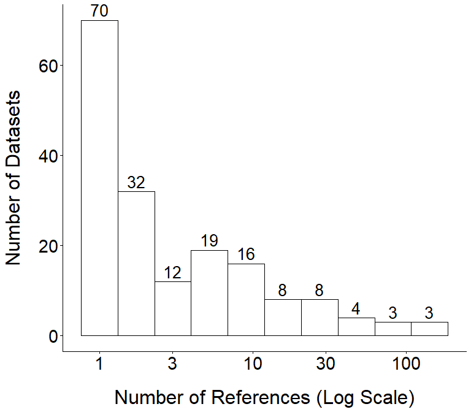

(a)

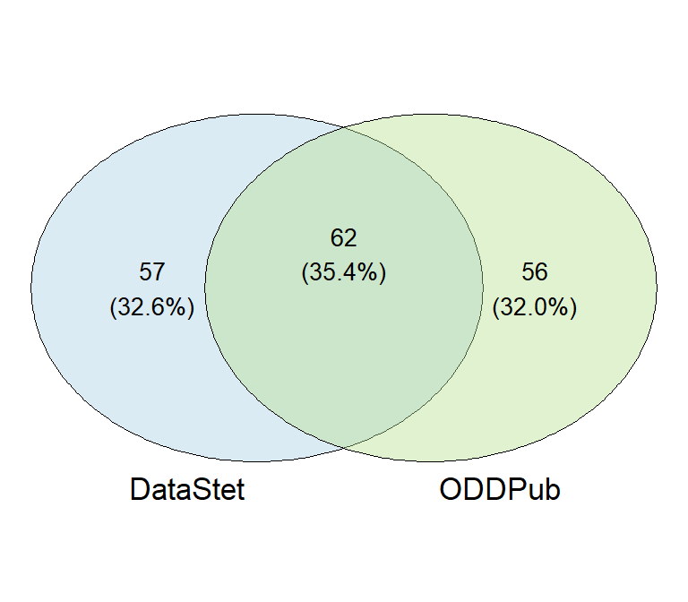

(b)

Figure 2: Frequency Distribution of Dataset References (N = 175). The histogram displays the number of times individual datasets were referenced across all referencing articles. The x-axis indicates the frequency of references per dataset, while the y-axis shows the number of datasets corresponding to each reference frequency. (b) Contribution of each data source to identified referenced datasets (N = 175). The Venn diagram shows the number of referenced datasets that originated from each source (ODDPub and DataStet), including the overlap between the sources. ODDPub includes datasets that were added using ODDPub-identified datasets as a seed.

## 3.2 Determinants of institutional dataset reuse

To better understand the patterns of institutional dataset reuse, we analyzed in which repositories the reused datasets were deposited. We observed that out of 175 datasets which had been referenced, 86 (49.1%) had been deposited in the Gene Expression Omnibus (GEO) (Figure 3). The overall pattern was very similar when looking at the distribution of dataset references across repositories, rather than the distribution of referenced datasets (Supplementary Figure 1). Overall, references were overwhelmingly to datasets from the fields of genomics and proteomics, i.e., sequences of DNA, RNA, and proteins. On the level of individual references, the ten most-referenced repositories contain datasets which are predominantly constituted by sequence data. Only 11 of 1,497 data references (0.7%) referred to datasets of other types, deposited in either disciplinary repositories (e.g. Electron Microscopy Data Bank, 4 references) or general-purpose repositories (e.g. Mendeley, 3 references). This clearly shows that ‘omics’ fields currently contribute the large majority of data references, and thus at least a major fraction of data reuse cases overall.

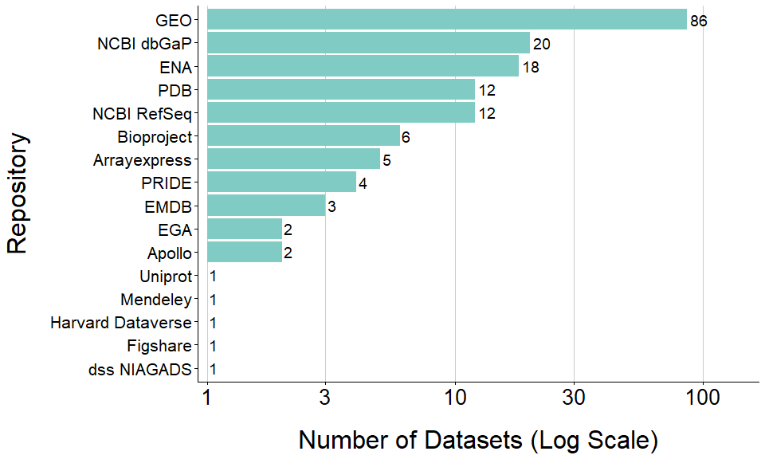

Figure 3: Distribution of Referenced Datasets across Repositories (N = 175). The bar plot displays the number of referenced datasets, split by the repository where data were deposited. Where the same number of datasets from multiple repositories was reused, these are listed in reverse alphabetical order.

We investigated further determinants of dataset reuse and found that human data, which constitutes 77.1% of all checked datasets, is used more often than non-human data (*p* = 0.01; Odds Ratio = 1.97; See Figure 4). We also observed that data reuse was more probable if data bore a relation to COVID-19 (*p* = 0.04; Odds Ratio = 2.32; See Figure 4). In addition, the location of data references in the original publication was also significantly correlated with data reuse, in that datasets listed in the data availability statement were **less** commonly reused (*p* < 0.001; Odds Ratio = 0.22). Overall, the logistic regression explained meaningful variation in dataset reuse ($\chi^2$(5) = 86.59, *p* < 0.001).

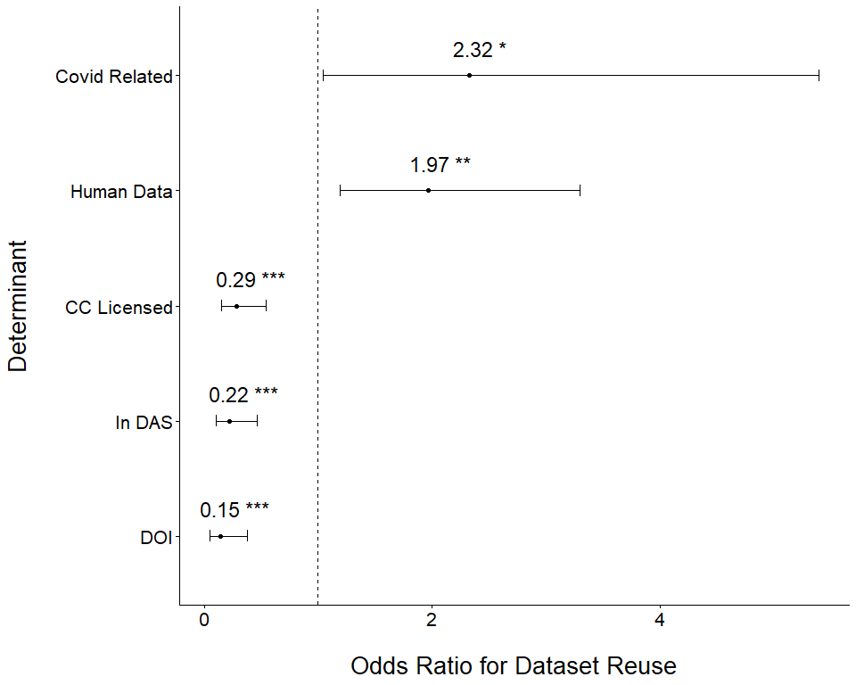

Figure 4: Determinants of Institutional Dataset Reuse. The figure shows odds ratios for inclusion in the DCC. 175 referenced datasets (i.e., datasets that were found in the DCC) and a sample of 200 datasets that were not found in the DCC were included in this analysis. Values >1 indicate higher odds and values <1 indicate lower odds. For example, human datasets have 1.97 times the odds of being reused (97% higher odds), whereas datasets with DOI identifiers have 0.15 times the odds of being reused (85% lower odds) compared with datasets with accession number identifiers. All odds ratios are adjusted, meaning that each estimate reflects the association between a given determinant and inclusion in the DCC, while controlling for the other determinants in the model. Significance levels are indicated as follows: *p < 0.05, **p < 0.01, ***p < 0.001.

Figure 5 presents an overall characterization of reused Charité datasets, with a focus on how these different characteristics are interrelated. It can be observed that reused datasets were, in their majority, shared openly, without either DOI or Creative Commons (CC) license. Restricted-access reused data were mostly shared through dbGaP. COVID-19-related data were mostly shared through GEO, EGA, and PDB.

[figure not shown]

Figure 5: Properties of Institutional Dataset Reuse (N = 175). The Sankey plot maps characteristics of mentioned datasets and the relations between them. The dataset properties displayed are, from left to right: (i) is the data identified using a DOI or an accession number, (ii) is the data shared with a CC license, (iii) is the data openly available or restricted-access, (iv) which repository is the data deposited in, (v) is the data collected from human subjects, and (vi) is the data related to COVID-19 research.

## 3.3 Data reuse as a function of dataset age

We investigated whether there is a correlation between dataset age and the number of references. This was done using a generalized linear mixed model (negative binomial) with the dataset’s identifier as a random effect (random-intercept SD = 0.83). This analysis is constrained by the fact that the large majority of datasets were published between 2020 and 2023, so it might not be representative of other time periods. Datasets published earlier could still be part of the analyzed set, and in this regard it is important to consider, as mentioned earlier, that the analyzed Charité articles were not necessarily the first ones to base their analyses on the respective datasets. Rather, these articles were only **the earliest detected** out of n≥1 instances where a dataset was, by our definition, shared by Charité authors. The overall development of citations over the first 3 years (Supplementary Figure 3) suggests that dataset references do not follow a clear trend in the first three years from the dataset’s publication (incidence rate ratio [IRR] = 0.93, 95% CI [0.81-1.05], *p* = 0.24). However, this analysis is strongly skewed by the datasets which are referenced only once. We thus generated a subset containing only datasets referenced at least once in the year the dataset was published and the three subsequent years (Figure 6). For this subset, consisting of only seven datasets, we observed a negative correlation, corresponding to an average 22% decrease in the number of citations per year. This association was, however, not statistically significant (IRR = 0.78, 95% CI [0.58-1.04], *p* = 0.09).

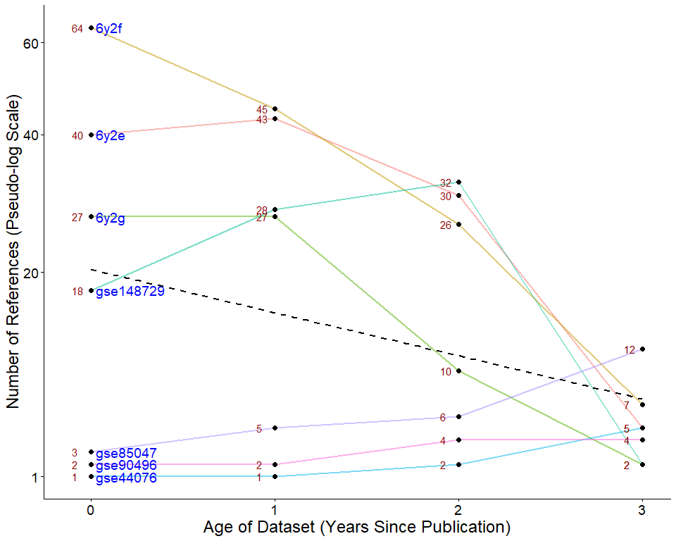

Figure 6: Distribution of References by Dataset Age. The plot shows the relation between the age of datasets and the number of times it was referenced. The plot includes only the seven most referenced datasets among the subset of those datasets which were referenced in all four age bins, i.e., 0, 1, 2, and 3 years after their publication. The dataset age (X axis) is the number of years that have passed between the dataset publication year and the publication year of the referencing article. Dataset identifiers are added in blue text, and the number of references during a particular age bin is added in red text. A pseudo-log transformation (base = 12, sigma = 10) was applied to the y-axis to improve visualization across the wide range of citation counts. The minimum observed citation count was 1. The dashed line displays the overall trend in the number of references over age bins for this subset of datasets.

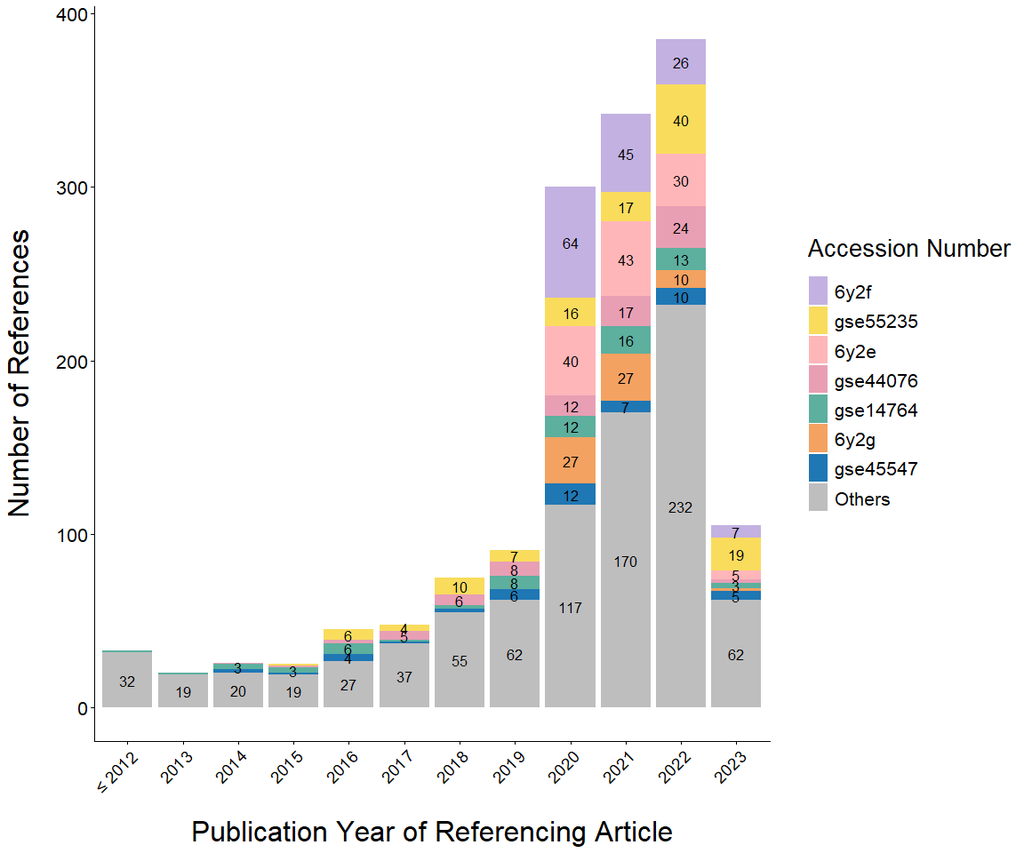

Figure 7: Distribution of References by Year (N = 1,495). The bar plot displays the frequency of dataset references across all referencing articles by the year of reference, defined as the publication year of the corresponding referencing article. The seven most frequently referenced datasets are highlighted by individual colors, while the sum of all other references is shown in grey. Two references from 2024 are not presented in the plot. Note that datasets were detected through Charité articles from the years 2020 to 2023, but these datasets could have already been shared with other, earlier articles. This explains the detection of referencing articles from before 2020.

## 3.4 Analysis of references to data articles

In addition to an analysis of data references, we conducted an independent analysis of indirect data citations. As described in detail in the methods section (see Section 2.8), this analysis is based on a forward citation search on a set of data articles. Subsequently, we manually detected whether a specific reference was pointing to the content of the data article itself, or was rather an indirect dataset citation, where the data article citation stood in for the dataset. In this analysis of data articles published between 2019 (i.e., starting a year earlier than the DCC analysis) and 2022 in the journals Scientific Data and Data in Brief (n = 21), we detected 35 shared datasets overall. These articles had been cited 1,728 times. In the five cases where data articles were cited >60 times, we restricted manual checks to 60 references. In this “truncated” set, we found that out of 537 references, 113 references (21%) were in fact indirect data citations. We used this to extrapolate numbers for the additional references to the five most-cited articles for which not all referencing articles could be screened. Adding these extrapolations, we estimated 846 citations for these 35 datasets (Figure 8 (a)). It should be mentioned that the overall number of indirect data citations is strongly impacted by one outlier, which received an extrapolated number of 662 references. However, even after removing this outlier, we would still estimate 184 indirect data citations. We also observed that these datasets were rarely published in omics repositories (only 5 out of 35 datasets; Figure 8 (b)), which suggests a very different pattern of sharing and reuse for datasets presented in data articles.

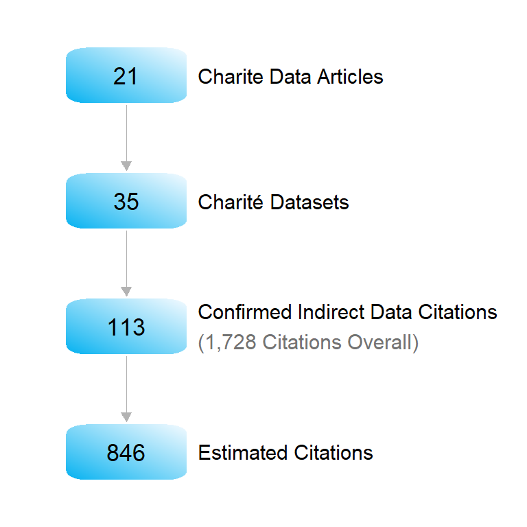

(a)

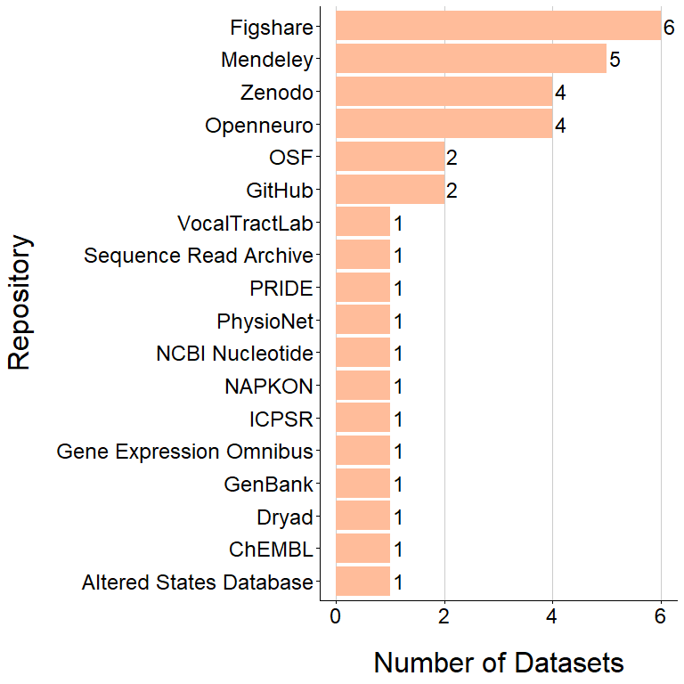

(b)

Figure 8: Overview of Charité Datasets Indirectly Cited through Data Articles. The flowchart diagram shows how many data articles were analyzed, the number of datasets shared, how often indirect data citations were detected, and how many were extrapolated based on the manually screened sample. (b) Distribution of repositories in which datasets shared with data articles had been deposited (N = 35).

# 4 Discussion

## 4.1 Detecting data reuse through the DCC

Using two approaches, we charted the reuse of datasets shared alongside articles published by researchers from our large biomedical research institution, the Charité - Universitätsmedizin Berlin. Our primary approach made use of the Data Citation Corpus (DCC) to detect references to reused datasets. Between 2020 and 2023, Charité researchers published (without considering the author position) 1,583 articles for which at least one dataset was shared, as detected using ODDPub, with 2,385 datasets overall. Out of the overall sample including these datasets as well as 119 datasets detected using DataStet, 175 datasets were referenced 1,497 times in 1,390 papers. This is, to our knowledge, the first analysis to quantitatively show at the scale of a research institution, how the datasets produced are reused and enter the published literature. Former work has focused on individual repositories (Strecker, Soltau, and Bach 2025) or research communities (Milham et al. 2018; Khan, Thelwall, and Kousha 2021) or has compared different disciplines (Yang and Colavizza 2025). In line with earlier work, we show that reuse of datasets is common in the biomedical domain. At the same time, 95.1% of datasets detected via ODDPub have not been referenced within the time period in question. A highly uneven distribution of dataset references across datasets is plausible based on the literature on article citations (Redner 1998; Brzezinski 2015), as well as the studies on dataset citations (Bai and Du 2022; Momeni et al. 2025) where they touched this topic. We did not investigate the fraction of dataset citations out of all dataset references to Charité articles. However, it has been shown repeatedly that the number of data citations alone is low. E.g., Ninkov et al. (2021) show that only ca. 1% of datasets in DataCite had a citation.

It has been described extensively before (e.g. Silvello 2018) that data citations can indicate both the sharing and the reuse of data. Correspondingly, we observed, in addition to 1,497 cases of dataset reuse (also see below for a discussion of data sharing vs reuse), 275 cases where authors referenced datasets they had themselves created, with this number applying to the subset of datasets detected using ODDPub. It is because of the exclusion of articles with author overlap (i.e., own data use), as well as the original Charité articles with which data had been shared, that our results do not contradict (Strecker, Soltau, and Bach 2025). The authors report for the RADAR repository that 27.9% of datasets were referenced, with 21.4% of these being data citations.

On a methodological level, we also show that a list of dataset identifiers can be matched to the DCC to obtain a corresponding list of data references. As we also describe, this process is far from straightforward, however. Even if the institutional data identifier list is highly standardized, the variability of dataset IDs in the DCC poses considerable challenges. The same dataset can be referred to in several ways, which makes the detection of references to general-purpose repositories particularly complex. Nevertheless, the DCC includes both data citations and data mentions, and thus has a much broader coverage than databases which build on citation metadata only. This is necessarily true for DataCite (analyzed e.g. by Ninkov et al. 2021) which constitutes the subset of data citations within the DCC. It has been shown for datasets in the earth sciences that proprietary databases, which include additional methods and sources, have better coverage (Gerasimov et al. 2024), and the analysis of Strecker, Soltau, and Bach (2025) has shown a better coverage of Google Scholar and DataCite Event Data compared to the DCC (see Section 4.3 for a discussion). Still, it is overall not yet sufficiently investigated, how other databases compare to the DCC.

## 4.2 Detecting data reuse by indirect citations of data articles

We complemented this approach by an analysis of references to data articles. We examined a sample of 21 data articles published by Charité researchers between 2019 and 2022 in the two most common, non-disciplinary data journals. These articles shared 35 datasets overall. We found 846 references to these datasets through Google Scholar, including extrapolated references (see below, as well as Section 2.8). Thus, indirect data citations constitute a substantial fraction of all instances in which data reuse is visible in the literature, and if they are not taken into account, a major fraction of institutional dataset references would be missed.

Our analysis has confirmed the finding of Jiao and Darch (2020) that it is common practice in the literature to refer to a data article instead of the data, when actually the data have been used. At the same time, not every reference to a data article indicates a reuse of the data. Jiao and Darch (2020) observed for two journals in the earth as well as physical and chemical sciences that 56% of citations to data articles indicate actual data reuse. Li, Huang, and Jeng (2025) observed a much lower fraction of just 11%. This lower number might partly be explained by their sampling, exclusively focused on data articles from *Data in Brief*, which we observed to have low reusability on average. In our case, 21.04% of citations to data articles (113 of 537) in fact referred to the underlying dataset (or one of several shared datasets). Thus, studies on the reuse of data need to take such “indirect citations” into account. These constitute a substantial fraction of all dataset references and could be of particular importance for some purposes of monitoring, as data articles could describe datasets of particular value, especially for communities where data sharing and reuse are not common. Also, we see indications that this sample is characterized by both data types and types of data reuse distinct from the sample found via the DCC. However, this warrants further research.

To extract the information whether a data article reference in fact referred to the underlying data was a manual task and thus time-consuming. Correspondingly, we had to limit ourselves to extracting up to 60 citations per data article. For five out of 21 articles, the number of citations exceeded this number. In these instances, we have extrapolated the number of expected data reuse cases based on the number of data reuse cases within the 60 citations we analyzed. This extrapolation yielded a staggering number of 662 putative data reuse cases for the most-cited dataset. While there is certainly an error margin attached to this number, it does clearly indicate the reuse value of certain unique and well-curated datasets.

## 4.3 Putative undetected data reuse

1. We extracted per article by Charité authors one dataset identifier per repository. However, especially for omics data, which are the most reused in our sample, it is common to share more than one dataset per repository. E.g., if an article shared 10 datasets in GEO, the probability of detecting a reuse case is thus only 10%, as we extracted only one out of these 10 identifiers (at least under the simplifying assumption that dataset citations are independent of each other). Thus, an unknown but substantial number of datasets is missing from our sample. We did extract ‘additional identifiers’ from articles for which the reuse of one dataset had already been detected. However, we missed all cases where not the “seed” identifier but another identifier, undocumented by us, had been referenced.
2. As the basis of data references in the literature, we used the DCC only. Strecker, Soltau, and Bach (2025) additionally used Google Scholar and DataCite Event Data, and observed that there was little overlap between the sources. In addition, they observed that the DCC had by far the lowest coverage containing only 6.1% of all references detected. We expect that the coverage of the DCC for our use case is far higher, both because of our extensive standardization and cleaning, and because of the nature of the references we aimed to detect (primarily mentions of reused data, rather than citations of own data). Nevertheless, the sources of data references in Strecker, Soltau, and Bach (2025) indicate that a substantial number of references was missed due to incomplete coverage in the DCC.
3. While some repositories create versioned identifiers (e.g. dbGaP, figshare) or allow additions to a deposit under the same identifier (e.g. GEO), in other cases new versions of a dataset receive a fully new identifier (e.g. Zenodo). In such cases, detection by our method becomes impossible.
4. The screen for shared datasets on which our analysis relies could not be performed on ca. 20% of all research articles published by our institution. These could not be accessed programmatically, either for licensing or for technical reasons.
5. We observed in the analysis of indirect data citations that those articles which cited the data article sometimes additionally referenced the dataset itself by its identifier. Where the data article text itself was the point of reference, and no indirect data citation occurred, such cases would have constituted additional dataset references. We did not extract these cases, however, and thus they are missing from the overall number of dataset references, as detected in the DCC analysis.
6. The DCC serves to analyze references to datasets which have identifiers, either persistent identifiers (typically DOIs) or accession codes. However, restricted-access data sharing typically takes place via platforms which do not provide either. In our sample, the only two restricted-access platforms were dbGaP and EGA. Thus, references to restricted-access datasets especially outside of omics fields would not have been detected.
7. We only extracted identifiers of shared datasets from the English-language literature.

It is also important to keep in mind that our definition of data reuse excludes any articles with author overlap. This includes cases where having contributed data is the primary scientific contribution to the article. Indeed, some consortia and data sharing platforms explicitly expect co-authorship for one or more original study PIs. These cases are not reuse by our definition, but they could be consistently construed as reuse cases. There is no obvious way, however, to detect such cases based on the literature alone. The inclusion of such data reuse cases which lead to co-authorship would increase the overall number of data reuse cases detected.

For the analysis of indirect data citations, these limitations do not apply, but we would expect to have missed references here for the following reasons:

1. We assume that indirect data citations are particularly common for data presented via data articles. However, it is to be expected that indirect data citation also occurs for other types of articles, which are cited instead of the data underlying them. This is suggested e.g. by the survey of Gregory et al. (2023), which shows that citing the article analyzing the data is much more common than citing the data itself. Such indirect data citations were missed by our analysis.
2. In the analysis of indirect references via data articles, we focused on the two most common, non-disciplinary data journals. However, a multitude of data journals, most of them disciplinary, exists, and many journals offer data articles as one of several article types (Kindling and Strecker 2022).

For the reasons described above, we expect that the actual volume of dataset reuse as reported in the literature is substantially larger than we report here. While no number can be attached to it, it is reasonable to assume that the overall number of references in the literature to datasets shared by Charité researchers is several times as large as the number we observe.

We searched for reuse of datasets associated with Charité publications starting in 2020. Although some datasets were older, the majority was published in temporal proximity to the article through which we detected it. Thus, at the time of the creation of DCC version 3, which we used (February 1<sup>st</sup>, 2025), most datasets were still comparatively new. The literature on data reuse (Vries, Siegle, and Koch 2022) as well as our own analyses (see Figure 7) indicate that dataset reuse accumulates over many years. Thus, we would expect an overall number of citations to be substantially larger, if we had screened an earlier section of the Charité literature. Correspondingly, the datasets we analyzed can be expected to accumulate many more references in the future.

On a more general note, the approach we follow can only capture one type of data reuse, namely the reuse which contributes to published research and is considered by researchers to be worthy of a reference. Data referencing practices differ between communities (Gregory et al. 2023), and it has been shown that not all data uses will be referenced in publications with equal probability. In addition, the extensive literature on publication bias (see e.g. Ioannidis 2005; Sena et al. 2010; Gougeon et al. 2025) suggests that many data reuse cases might not be reported as the project they are part of is itself not published. Lastly, certain reuse purposes, in particular teaching, typically do not contribute to academic publishing, and thus cannot at all be detected.

## 4.4 Determinants and patterns of data reuse

We compared the 175 reused datasets, as detected via the DCC, with a random sample of 200 datasets which had not been referenced. We observed significant associations with all five putative predictors we investigated, but not all seem meaningful to us. The most important finding is that the probability of human data to be reused is nearly twice as high as for non-human data. A causal influence of data provenance on reuse seems plausible in this case. If so, this would lead us to conclude that, while sharing human data is more complex for ethical and data protection reasons, this effort is also rewarded by a higher impact on the literature. The reasons would warrant deeper investigation, but it seems plausible that the higher effort to collect human data would contribute to this effect. Another predictor which was positively correlated with data reuse is a relation of the data to COVID-19. This is based on a small sample (19 of 175 referenced datasets had a COVID relation), but a higher rate of reuse for COVID data seems plausible, as data reuse increased in the pandemic (Digital Science et al. 2021) and some of the most-referenced datasets in our sample were related to COVID.

In addition, we observed negative correlations with three additional predictors. However, in all three cases we interpret these correlations as spurious. We observed that the probability of data reuse is much **lower** for data with a DOI and data with a CC license, as well as for data mentioned in a DAS. The first two observations, which seem counterintuitive at first, can be explained by the higher reuse probability for datasets from disciplinary as opposed to general-purpose repositories, in conjunction with differing approaches to assigning identifiers between repositories. Within the top five most-referenced repositories (GEO, PDB, dbGaP, NCBI RefSeq, ENA), only PDB assigns DOIs, and even in this case the reference used in articles is overwhelmingly to the accession code rather than the DOI. At the same time, general-purpose repositories, which all assign DOIs, constitute only a small fraction of the DCC, and even this small number is not reflected in the reuse of Charité datasets. Thus, the negative correlation between dataset reuse and the use of both DOIs and CC licenses is highly likely a collateral effect of the much higher reuse probability for data deposited in disciplinary repositories, many of them offered by the NIH for omics fields, which currently rarely assign DOIs or offer to select CC licenses. It remains open whether the comparatively high reuse of data from these repositories occurs **despite** the lack of DOI and CC licenses, or whether this has no effect on reuse whatsoever. We had conducted this analysis based on the hypotheses that DOIs and CC licenses would both **increase** data reuse. DOIs and persistent identifiers generally are broadly recommended (GO FAIR initiative, n.d.; STM Association, DataCite, & Crossref, n.d.), facilitate the registration of datasets in search engines (Contaxis et al. 2022), and reduce link rot (CLARIN, n.d.). CC licenses are also broadly recommended (NFDI4Chem, n.d.; Helmholtz Open Science Office, n.d.; MPDL, Research Data Management, n.d.) as they reduce legal uncertainty (Labastida and Margoni 2024), while a lack of standardized licenses creates “significant reuse and interoperability barriers” (Carbon et al. 2019). The remaining observation that datasets **not** mentioned in a DAS have a higher probability of being reused is more puzzling. We had hypothesized that datasets mentioned in a DAS would be reused more often, based on Contaxis et al. (2022). The most probable explanation seems to be an interplay of research field and prevalence of DAS in journals from this field, but we did not investigate this further. It should also be kept in mind that the Charité article sharing the dataset must not have necessarily been the **first** article to do so (see Section 2.6), and thus, some datasets might have been found by re-users through other, earlier articles where the dataset was more clearly marked. Also, this analysis does not differentiate between data references outside of a present DAS and articles without a DAS, and it was based on a very skewed sample, as of 200 datasets not referenced, only 7% were not mentioned in a data availability statement. Nevertheless, summing up these three negative correlations, it can be said that the overall compliance of datasets with FAIR criteria or the findability through DAS is not the determining factor for data reuse. If the repository practices investigated did have the expected positive impact on reuse, it cannot be detected against the backdrop of the specific practices followed by a set of highly-used disciplinary repositories.

Most reused datasets were shared via disciplinary repositories, substantially beyond the fraction expected based on both the overall sample of Charité datasets and the distribution within the DCC. Amongst the datasets shared by Charité researchers in 2023, 31.6% of datasets (137 out of 433) were deposited in general-purpose repositories. In DCC version 3 used in our analysis, 36% of identifiers in the DCC were DOIs, and thus typically deposits in general-purpose repositories, and 64% were accession numbers. However, these fractions of 31.6% and 36%, respectively, are not reflected in the reuse patterns we observe. Data from disciplinary repositories are reused much more often, with a large majority of datasets coming from omics fields. The eight repositories with the highest number of reused datasets corresponded to omics fields, and these accounted for 163 of 175 reused datasets in the DCC analysis. Data deposited in disciplinary repositories of other disciplines and general-purpose repository data were a minor fraction, with only five datasets in general-purpose repositories being reused. This pattern is also seen in the reuse of data **by** Charité researchers, using an exploratory analysis which included only articles from the year 2023 and applied less strict criteria for open data. We found that out of 764 reused datasets, only 56 (7.3%) were shared in general-purpose repositories.

The picture was starkly different for indirect data citations, however, where only 5 of 35 datasets were shared in omics repositories, and the vast majority of indirect data citations was to other types of data, the majority of which (20 out of 35) was deposited in general-purpose repositories. This is in contrast to the DCC analysis, which showed very low rates of reuse for data from general-purpose repositories. Taken together, these results indicate that data in general-purpose repositories can be of high reuse value, but their reuse, and possibly indeed their reusability, is mediated by the presence of associated data articles. We see a multitude of factors which could contribute to higher rates of reuse for data shared with data articles: (i) visibility, (ii) trust, (iii) extensive description of data, (iv) higher quality through curation, and (v) higher quality due to selection bias. More research is needed on which of these or possibly other factors contribute to the mediating role of data articles for reuse of datasets in general-purpose repositories, and to which extent. Where data are not accompanied by a data article, their reusability seems much higher for data deposited in disciplinary repositories as compared to general-purpose repositories. This predominance occurs despite substantially lower FAIRness scores in general-purpose repositories (“Charité Metrics Dashboard: Data Reusability (FAIR Data),” n.d.). The higher reusability of data in disciplinary repositories is also supported by the observation that even within the indirect data citation sample, the datasets which were most referenced were shared via disciplinary repositories, interestingly outside of omics fields (ICPSR for social sciences, OpenNeuro for neuroimaging, PhysioNet for physiology).

In our exploratory analysis of the development of dataset reuse over time, we observed that data are reused over several years after publication. For the most-referenced datasets we observed a trend for a maximum of references to be reached right after publication, with a subsequent decrease in references. However, we interpret this as a spurious effect due to a peak in the use of COVID-19-related datasets during the first two years of the pandemic. The four datasets which were cited most and which contribute most to this temporal pattern are all related to COVID. This interpretation is also supported by our observation that COVID-related datasets had a higher probability to be referenced on the dataset level, i.e., disregarding the number of references a dataset accrued. Overall, we observed a varied pattern over time, with some datasets increasing the number of references within the first three years after publication.

## 4.5 What is data reuse anyway?

In this article, we have taken a pragmatic approach to data reuse. We have assumed data reuse to have taken place, if three conditions were fulfilled:

(1) a research article referenced a dataset

(2) this dataset is available either openly or with a defined access pathway; for the DCC analysis, a dataset identifier was required

(3) the article referencing the data and the article for which we had originally detected data sharing (or the data article) had no author overlap (or else this was defined as “own data use”)

However, this operationalization is simplified and requires qualification. It has been argued by Sandt et al. (2019) that reuse cannot at all be defined. At the same time, it is common in the research community to distinguish between “own data use” and “data reuse”. Gregory et al. (2023) adopted the definition that “data reuse” means “using data which others have created, for any purpose.” The notion that use and reuse can be distinguished to us seems intuitive as well as useful to inform ways to measure the value created by data sharing. We would argue that it is intuitive based on common notions related to data creation, stewardship, and usage rights. It is also useful to inform policy and support activities. However, a notion being intuitive and useful does not necessarily make it conceptually consistent. On the legal level, data cannot be owned at least in some jurisdictions, as e.g. in Germany (BMWK, n.d.), and “data ownership is an inherently problematic concept from a legal perspective” (Publications Office of the European Union and Graux 2024). Questions of data ownership are linked to the view widely held by researchers that data are intellectual property of some sort (whether this is legally enforceable or not). Taken together, this leaves open whether a clear line between an “owner” (or, possibly, “creator”) and a “non-owner” (or, possibly, “non-creator”) can be drawn, and whether a consistent and at the same time useful definition of what “data reuse” means is achievable.

Beyond the fundamental question of defining own data use vs. data reuse, further practical challenges are posed by our bibliographic approach. Even if “own data use” and “data reuse” can be clearly separated conceptually, the question still remains whether bibliographic information can provide sufficient information to make such a distinction. However useful such a distinction based on bibliographic data might be in practice, it requires additional assumptions which are not necessarily in line with scientific practice, or at least not universally accepted. Consider the real-world case of a database which makes datasets available, but requires that investigators from the original project are included as co-authors on analyses using this data. By our definition, the resulting articles would constitute cases of “own data use”. However, as the article content is based on data shared by investigators not otherwise involved, value has been created by making data available to “others”. Thus, the data sharing constitutes the very link between the core group of investigators and the data contributors. Correspondingly, the notion that “reuse” is “use for a different purpose”, independently of authorship, is also widely held and so intuitive that Gregory et al. (2023), despite the definition given above, also state that “roughly three-quarters of respondents […] reported reusing [sic] their own data multiple times”. We cannot resolve this fundamental tension, but for our analysis, we settled on what we see as a pragmatic position, based on author overlap. The views described above show the need for a community consensus on what constitutes data reuse. The FORCE11 Working Group “Data usage typologies” (FORCE11, n.d.) has created a Data Usage Typology (Bobrov et al. 2026) to support conceptual clarity around data use and reuse, and as of mid 2026 works on implementing this typology in metadata standards.

Data references can be indicative of data reuse, but similar to views or downloads of datasets, they do not constitute data use in themselves, and assumptions have to be made for their interpretation. In the aforementioned criteria for the detection of data reuse cases, we do NOT require that a dataset has been analyzed or in any other way handled on the level of the data files themselves. Thus, we adopt a wide definition of data reuse, which does not require any specific purpose or function. We assume that datasets are most commonly referenced when data have been “used” in the sense that an interaction with at least a subset of files constituting the dataset has taken place. However, there are other ways to make use of datasets (Gregory et al. 2023; Banaeefar et al. 2022), and data can be referenced even if no interaction with the data files took place, e.g. to legitimize own work or to leverage the dataset as support for scientific claims made in research articles. Lafia et al. (2023) analyze in detail, which functions data references serve. Their typology describes five functions of data references, being “critique”, “describe”, “illustrate”, “interact”, and “legitimize”. Whether all of these types of data reference are indicative of data reuse, depends entirely on the definition of data use (and thus, reuse) applied. The observations by Lafia et al. (2023) that only a subset of references indicates “interactions” with the dataset and by Gregory et al. (2026) that data are referenced for many reasons strongly suggest that not all references to datasets we observed are indicative of active engagement with the data. As we did not restrict our analysis to instances of proven interaction with datasets, we could also not investigate specific types of interaction, as e.g. replication and re-analysis. An additional consideration given our inclusion of all types of data reference, regardless of purpose, is to assess which kind of value is created by other types of data reuse than “interaction”, and whether these other uses are then still in scope for the monitoring exercise conducted. We assume that every data use has contributed at least **some** value. While we cannot estimate this value for different types of use, we would like to point out that the same question of case-specific value is also true for article publications. Thus, any assessment of the relationship between data references and value creation should be interpreted in light of similar assessments of the relationship between article references and value creation.

Lastly, it is also important to mention that we understand “data” throughout this article as a shorthand for “datasets”. It is datasets which are shared and it is datasets which are reused. Any piece of information which can be used to support a claim can be understood as “data”, but this would not be a useful category for our purposes. In line with this understanding, we have excluded cases of databases which contain “information” as e.g. the association between a certain disease and a certain mutation, but not a “dataset” in the sense of structured information which can be downloaded and processed further. Necessarily, the distinction between data and datasets is a matter of definition and remains contentious, as is the related distinction between data and metadata.

## 4.6 Limitations

The following restrictions and limitations apply to our analysis:

- We only detect reuse cases indicated by references in the published literature. This excludes many types of data reuse, as described in Section 4.3. In addition, dataset reuse by commercial actors is common and cannot be detected via bibliographic methods (Ross et al. 2024).
- We do not distinguish between reuse of the dataset by directly employing it and referencing it for comparison or context. We conceptualize all references as “reuse”, but some authors as e.g. Yang and Colavizza (2025) make such a distinction, which requires deeper text analysis. Based on their work, it is expected that the majority of data references indeed indicate reuse by their definition, as they found 2.9 times more cases of “reuse” than “referencing”.
- ODDPub has been developed to detect dataset references in article full texts. If shared dataset identifiers were listed in the reference list only, and not in the article text, they might not have been detected. However, while formal citation of datasets is best practice, it is still highly uncommon (Ninkov et al. 2021; Park, You, and Wolfram 2018), and thus we do not expect to have missed a substantial number of datasets.
- Over the years, our criteria for inclusion have somewhat changed. For instance, we decided at some point to include a “persistence” requirement, which leads e.g. to the exclusion of deposits on GitHub. However, given the reuse cases we detected up to now (mostly accession codes in disciplinary repositories), it seems probable that this drift over time did not influence our analysis as described here.
- When we speak of datasets “from our institution”, we refer to datasets underlying articles with at least one co-author from the Charité. This does not imply that the dataset was actually generated or shared by Charité authors. This would be impossible to know from the literature alone.
- The article we determined as sharing data doesn’t have to be the first one to have shared the data, and this is indeed what we observed. We detected **one** paper from the Charité which shared the data, but it doesn’t have to be the first one.
- The large majority of datasets were published between 2020 and 2023, so the findings might not be representative of other time periods. This is in particular due to overlap with the COVID-19 pandemic, which might have led to transient changes regarding which datasets were predominantly shared and reused. The analysis of the development of dataset reuse over time is exploratory and needs to be interpreted with particular caution due to both the small sample and the short time window.
- We have addressed some data quality issues of the DCC by cleaning steps. However, there are no studies as yet investigating potential bias in the DCC, which could affect e.g. certain disciplines, repositories, or identifier types. Thus, it is unclear how faithfully the DCC represents the complete body of dataset references in the literature, and results e.g. on repositories or determinants of data reuse could be systematically skewed.
- Our definition disregards the question of dataset authorship, and we analyze article authorship only. Unfortunately, not all repositories provide authorship information, but where it is available it would be possible to define reuse as a lack of authorship overlap between an article and a dataset. This could be more reflective of actual data sharing and reuse processes, but whether it really is would warrant further investigation.

For steps to ensure the validity of data, see the methods section (Section 2).

## 4.7 Outlook

In this article, we show the extent of the reuse of biomedical research data associated with a specific research institution. In addition, we provide an analysis of the patterns of data reuse and its determinants. We observed a large extent of data reuse, which, however, spreads very unevenly across datasets. The majority of biomedical data reuse takes place for data from omics fields, shared via disciplinary repositories. Data articles are often cited instead of referencing the underlying datasets, and in these cases the research fields generating the data are much more diverse, with the majority of datasets shared via general-purpose repositories. As discussed in Section 4.3, we expect that a large fraction – and probably a majority – of data reuse cases still goes undetected. We recommend to address some of these limitations in future studies. The combination of different sources of data references, in addition to the DCC, could be particularly fruitful for a full picture. In addition, it would be highly useful to start from data access and quantitatively determine all purposes of data use, which often go beyond the uses visible in research articles. The Data Usage Typology (Bobrov et al. 2026) might help to capture some of this information on the repository level, although for repositories which do not require registration for download a full picture will remain very difficult to determine. In addition, repositories could also leverage the DCC to increase the visibility of data reuse by exposing reuse information on dataset landing pages. Going beyond the types of links we have analyzed, it would be highly informative to investigate the individual contributor roles and in which way datasets link authorship collectives. This would also help to overcome the simplistic dichotomy of “own data use” vs. “data reuse”. A further important addition to the picture would be a long-term analysis of data use, which goes beyond our time window of one to four years for most datasets.

One of the resource-intensive steps in our analysis was the standardization and cleaning of the DCC. Data quality in the DCC has been addressed before, although not in the reviewed literature (Page 2024). The author highlighted several issues with the DCC which we also observed, including erroneous attribution of repositories, multiple entries for the same repository with slightly different spelling and in particular many supposed data identifiers actually being links to supplements on publisher websites. The current DCC version is v4, and over the different iterations many issues have already been addressed. This is shown e.g by the quantitatively most impactful cleaning step, in which over four million duplicates were removed (DataCite 2024). It is to be expected that the quality will increase further, both due to feedback from users and, potentially, through the use of more sophisticated algorithms. At the same time, the difficulty to establish a comprehensive record of data references also highlights the unresolved problem of missing citations to datasets in reference lists. In the short term, to allow for a wider use of the DCC, we suggest additional data cleaning and standardization steps, as well as a documentation of the form into which identifiers from common repositories have been transformed. In the long term, thorough bibliographic studies on the completeness, correctness, and possible bias in the DCC are needed as well.

From the institutional perspective, given the small number of data articles and their comparatively large impact (not just on indirect data citations, but also on citations overall), it could be efficient to raise awareness for this format and actively support it for valuable datasets outside of omics fields. However, the pool of such datasets, especially for human data underlying data protection frameworks, is not known, and we do not have an overview of data articles in disciplinary journals. It would also be informative to analyze the sharing and reuse patterns in more detail, including a comparison of Charité data reuse with data reuse by Charité researchers. This could surface both areas where the institution is very strong with regard to its data impact, and areas where data are either shared or reused below the expected level. On the level of individual researchers, the references to datasets we analyzed could be used to inform about the reuse of shared datasets. We assume that this would be of major interest to at least some of the data providers, and could result to be a relevant motivational factor regarding data sharing in the future. This seems plausible, but despite a body of literature on researcher motivation to share data (Fecher, Friesike, and Hebing 2015; Zuiderwijk, Shinde, and Jeng 2020; Rosenbloom 2025), there seems to be no explicit investigation of the impact of reuse on sharing motivations. Possibly this is because until recently there was no way to show to researchers at scale, how the data they shared had been reused. In such communication to researchers, the limitations of the study need to be considered, in particular that referencing a dataset often but not always means the data has been reused. In addition, the communication cannot be targeted specifically to those researchers who created, curated and/or deposited the dataset. Although we don’t consider it likely, such communication could trigger broader discussions around the value of data sharing, which might revolve around most data not being referenced. In such a discussion, it would be important to highlight that a large fraction of references was probably missed, that datasets continue to accrue references over longer periods of time, and that value can also be created e.g. by increasing transparency and trust. Also, this finding can be put in context by referring to the highly skewed distribution of article references and the comparably low effort of sharing a dataset vis-à-vis typical research project durations. We see potential to reuse the procedure described here to conduct similar analyses at other institutions. The overview of institutional datasets we had before collated was very comprehensive and included time-consuming validation steps. However, it would be a valid approach to match all datasets by an institution’s researchers to the DCC, regardless of the compliance of these datasets with specific open data criteria. It would have to be minimally ensured, however, that the datasets matched to the DCC are really own and not reused datasets. Alternatively, identifiers of published datasets could be collected as part of an institutional bibliography.

With our analysis we contribute to developing an evidence base for questions around data reuse practices, but even more so around the expediency of data sharing. Ideally, to inform data sharing activities on the individual and the institutional level, much more information would be needed. This includes not only the overall extent of data reuse for different purposes and by different actors, but also the effort required to share data, which is inherently difficult to approach. In addition, amongst the many interactions to be considered, reuse of data by others could also motivate to reuse data oneself, increasing efficiency. Not least, in assessing overall expediency, the data citation advantage (Colavizza et al. 2020, 2024; Apartis et al. 2025) to article publications and the trust conferred by the sharing of data needs to be taken into account (Abele-Brehm et al. 2019). Against this background, a comprehensive, context-specific framework to determine the expediency of data sharing seems hardly feasible, but despite considerable unknowns, this topic needs to be approached, and with our study we contribute evidence for this discussion.

# 5 Data and code availability statement

Analyses were conducted in R version 4.3.3 (2024-02-29 ucrt) using RStudio 2024.4.0.735 and Quarto 1.6.42. A reproducibility package which includes data, code, and text is deposited on GitHub at https://github.com/quest-bih/Mapping-the-reuse-of-biomedical-research-data, release v1.0.3. This release has been deposited in Zenodo under the concept DOI https://doi.org/10.5281/zenodo.19235630 (Cohen et al. 2026), and the DOI has been added to the README file in GitHub. New versions of the article will be accompanied by new releases in GitHub and new versions of the deposit in Zenodo.

# 6 Declarations

- This project did not receive any dedicated funding.
- The authors declare that they have no conflicts of interest.
- Author Contributions:
  - Avihay Cohen https://orcid.org/0000-0002-0829-0810: Data curation, Formal analysis, Investigation, Software, Validation, Visualization, and Writing - original draft.
  - Blanka Ivanović https://orcid.org/0000-0003-4915-6818: Data curation, Investigation, Validation, and Writing - original draft.
  - Anastasiia Iarkaeva https://orcid.org/0000-0002-7370-1663: Validation and Writing - review & editing.
  - Vladislav Nachev https://orcid.org/0000-0003-0521-6153: Methodology, Software, and Writing - review & editing.
  - Evgeny Bobrov https://orcid.org/0000-0002-2368-464X: Conceptualization, Methodology, Project administration, Supervision, Validation, Writing - original draft, and Writing - review & editing.

# 7 Supplementary Materials

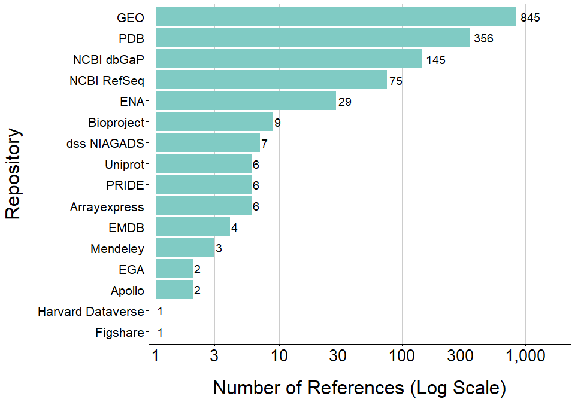

Supplementary Figure 1: Distribution of References across Repositories (N = 1,497). The bar plot shows the frequency of dataset references by repository across all referencing articles. Individual datasets may be counted multiple times per repository if they were referenced more than once. The figure is based on 175 referenced datasets.

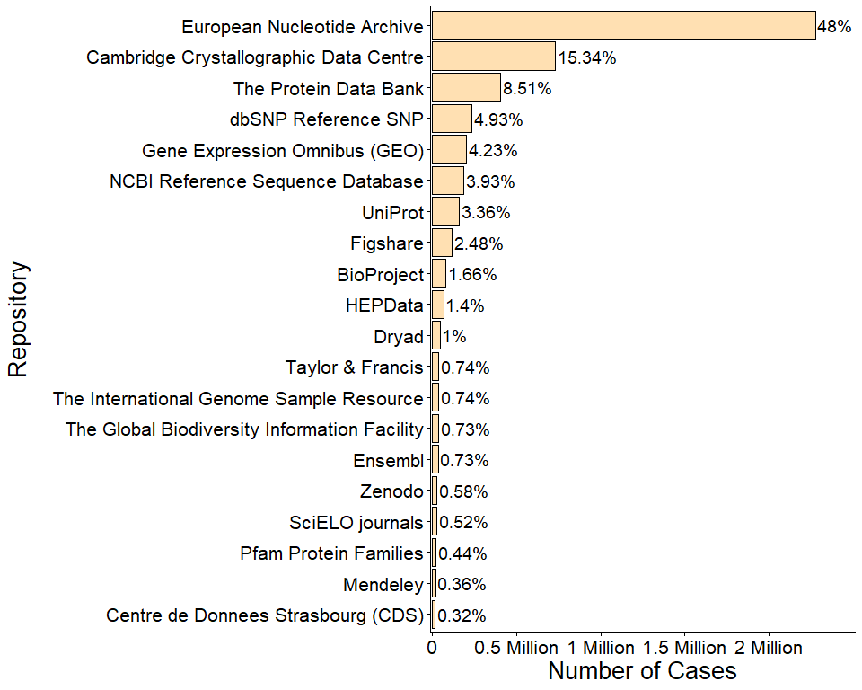

Supplementary Figure 2: Distribution of the 20 Most Prevalent Repositories in the DCC (N = 4,742,484). The bar plot shows the number of records associated with each repository across all articles listed in the DCC. Note that some DCC entries contain values in the ‘repository’ field which are in fact indicative of publishers rather than repositories.

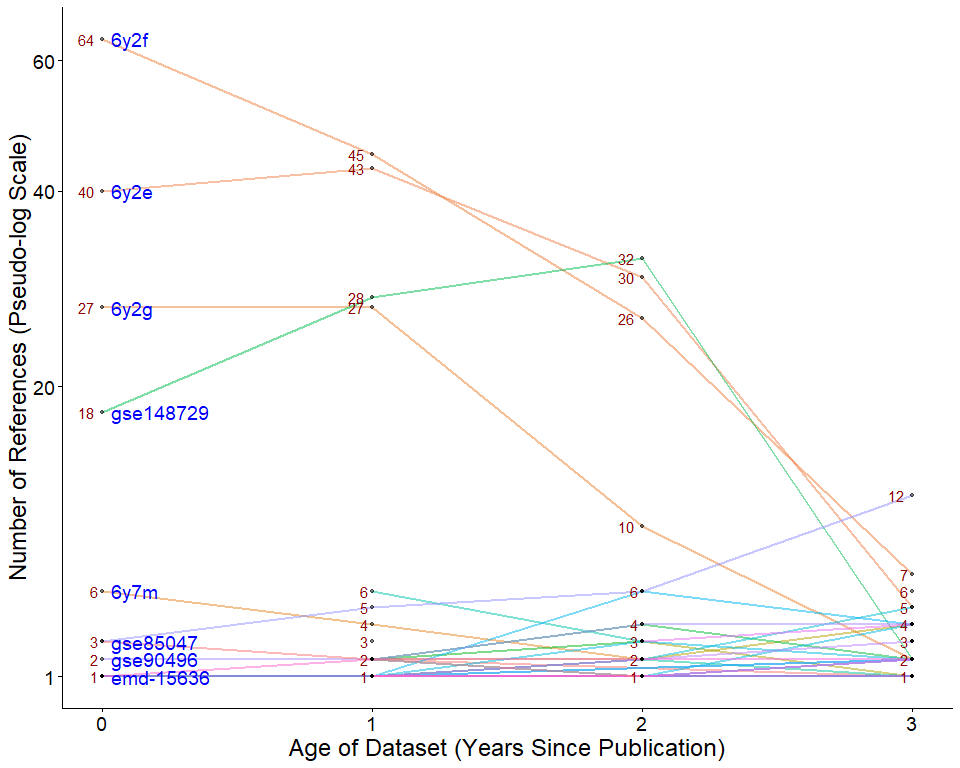

Supplementary Figure 3: Distribution of References by Dataset Age. The plot shows the relation between the age of datasets and the number of times it was referenced. The dataset age (X axis) is the number of years that have passed between the dataset publication year and the publication year of the referencing article. Dataset identifiers are added in blue text, and the number of references during a particular age bin is added in red text. The figure includes all reused datasets that were referenced in at least one of the four ages, i.e., 0, 1, 2, and 3 years after their publication (N = 123), many of which are used only once. A pseudo-log transformation (base = 12, sigma = 10) was applied to the y-axis to improve visualization across the wide range of citation counts. The minimum observed citation count was 1.

## References

Abele-Brehm, Andrea E., Mario Gollwitzer, Ulf Steinberg, and Felix Schönbrodt. 2019. “Attitudes Toward Open Science and Public Data Sharing: A Survey Among Members of the German Psychological Society.” *Social Psychology* 50 (4): 252–60. https://doi.org/10.1027/1864-9335/a000384.

Apartis, S., G. Catalano, G. Consiglio, R. Costas, E. Delugas, M. Dulong de Rosnay, I. Grypari, et al. 2025. *Open Science Impact Indicator Handbook* (version 1.0.1). Zenodo. https://doi.org/10.5281/zenodo.14651106.

Bai, Yongmei, and Jian Du. 2022. “Measuring the Impact of Health Research Data in Terms of Data Citations by Scientific Publications.” *Scientometrics* 127 (12): 6881–93. https://doi.org/10.1007/s11192-022-04559-4.

Banaeefar, Homeyra, Sarah Burchart, Elizabeth Moss, and Eszter Palvolgyi-Polyak. 2022. “Best Practice May Not Be Enough: Variation in Data Citation Using DOIs.” https://hdl.handle.net/2027.42/172780.

Barlösius, Eva. 2023. ““We Share All Data with Each Other”: Data-Sharing in Peer-to-Peer Relationships.” *Minerva* 61 (2): 243–63. https://doi.org/10.1007/s11024-023-09487-y.

Bassinet, Aricia, Laetitia Bracco, Anne L’Hôte, Eric Jeangirard, Patrice Lopez, and Laurent Romary. 2023. “Large-Scale Machine-Learning Analysis of Scientific PDF for Monitoring the Production and the Openness of Research Data and Software in France.” https://hal.science/hal-04121339.

BMWK. n.d. “FAQ Datenhoheit.” https://www.digitale-technologien.de/DT/Redaktion/DE/Standardartikel/FAQ-Recht/datenhoheit.html.

Bobrov, Evgeny, Reyna Broadhurst, Neil Byers, Christopher Erdmann, Francoise Genova, Maggie Hellström, Jennifer Kemp, Iratxe Puebla, and FORCE11 Data Usage Typologies Working Group. 2026. “Typology of Data Uses: An Output of the FORCE11 Data Usage Typologies Working Group,” March. https://doi.org/10.5281/zenodo.19184004.

Bobrov, Evgeny, Nico Riedel, and Miriam Kip. 2024. “Operationalizing Open and Restricted-Access Data—Formulating Verifiable Criteria for the Openness of Data Sets Mentioned in Biomedical Research Articles.” *Quantitative Science Studies* 5 (2): 383–407. https://doi.org/10.1162/qss_a_00301.

Borgman, Christine L., and Paul Groth. 2025. “From Data Creator to Data Reuser: Distance Matters.” *Harvard Data Science Review* 7 (2). https://doi.org/10.1162/99608f92.35d32cfc.

Brzezinski, Michal. 2015. “Power Laws in Citation Distributions: Evidence from Scopus.” *Scientometrics* 103 (1): 213–28. https://doi.org/10.1007/s11192-014-1524-z.

Callaghan, Sarah, Steve Donegan, Sam Pepler, Mark Thorley, Nathan Cunningham, Peter Kirsch, Linda Ault, et al. 2012. “Making Data a First Class Scientific Output: Data Citation and Publication by NERC’s Environmental Data Centres.” *International Journal of Digital Curation* 7 (1): 107–13. https://doi.org/10.2218/ijdc.v7i1.218.

Carbon, Seth, Robin Champieux, Julie A. McMurry, Lilly Winfree, Letisha R. Wyatt, and Melissa A. Haendel. 2019. “An Analysis and Metric of Reusable Data Licensing Practices for Biomedical Resources.” *PLOS ONE* 14 (3): e0213090. https://doi.org/10.1371/journal.pone.0213090.

Carlisle, Benjamin Gregory. 2014. *Numbat Systematic Review Manager*. Berlin, Germany: The Grey Literature. https://numbat.bgcarlisle.com.

“Charité Metrics Dashboard: Charité Dashboard on Responsible Research.” n.d. https://quest-dashboard.charite.de/#tabStart.

“Charité Metrics Dashboard: Data Reusability (FAIR Data).” n.d. https://quest-dashboard.charite.de/#tabFAIR.

CLARIN. n.d. “Persistent Identifiers.” https://www.clarin.eu/content/persistent-identifiers.

Cohen, Avihay, Blanka Ivanović, Anastasiia Iarkaeva, Vladislav Nachev, and Evgeny Bobrov. 2026. “Matching Data References and Institutional Output to Map the Reuse of Biomedical Research Data (V1.0.3).” Zenodo. https://doi.org/10.5281/ZENODO.19235630.

Colavizza, Giovanni, Lauren Cadwallader, Marcel LaFlamme, Grégory Dozot, Stéphane Lecorney, Daniel Rappo, and Iain Hrynaszkiewicz. 2024. “An Analysis of the Effects of Sharing Research Data, Code, and Preprints on Citations.” *PLOS ONE* 19 (10): e0311493. https://doi.org/10.1371/journal.pone.0311493.

Colavizza, Giovanni, Iain Hrynaszkiewicz, Isla Staden, Kirstie Whitaker, and Barbara McGillivray. 2020. “The Citation Advantage of Linking Publications to Research Data.” *PLOS ONE* 15 (4): e0230416. https://doi.org/10.1371/journal.pone.0230416.

Contaxis, Nicole, Jason Clark, Anthony Dellureficio, Sara Gonzales, Sara Mannheimer, Peter R. Oxley, Melissa A. Ratajeski, et al. 2022. “Ten Simple Rules for Improving Research Data Discovery.” *PLOS Computational Biology* 18 (2): e1009768. https://doi.org/10.1371/journal.pcbi.1009768.

Crossref. n.d. “Data Citations.” Website. Crossref. https://www.crossref.org/documentation/retrieve-metadata/data-citations/.

“Dashboard Page - Data Citation Corpus.” n.d. https://corpus.datacite.org/dashboard.

DataCite. n.d. “Consuming Citations and References.” DataCite Support. https://support.datacite.org/docs/consuming-citations-and-references.

DataCite, Make Data Count. 2024. “Data Citation Corpus Data File.” DataCite. https://doi.org/10.5281/zenodo.13376773.

Digital Science, Natasha Simons, Greg Goodey, Megan Hardeman, Connie Clare, Sara Gonzales, Damon Strange, et al. 2021. “The State of Open Data 2021.” Report. Digital Science. https://doi.org/10.6084/m9.figshare.17061347.v1.

EOSC EDEN. n.d. “Eden Project- about Us.” https://eden-fidelis.eu/about-us.

Fecher, Benedikt, Sascha Friesike, and Marcel Hebing. 2015. “What Drives Academic Data Sharing?” *PLOS ONE* 10 (2): e0118053. https://doi.org/10.1371/journal.pone.0118053.

FORCE11. n.d. “Data Usage Typologies FORCE11.” https://force11.org/group/data-usage-typologies/.

Gerasimov, Irina, Binita KC, Armin Mehrabian, James Acker, and Michael P. McGuire. 2024. “Comparison of Datasets Citation Coverage in Google Scholar, Web of Science, Scopus, Crossref, and DataCite.” *Scientometrics* 129 (7): 3681–3704. https://doi.org/10.1007/s11192-024-05073-5.

GO FAIR initiative. n.d. “F1: (Meta) Data Are Assigned Globally Unique and Persistent Identifiers.” GO FAIR. https://www.go-fair.org/fair-principles/f1-meta-data-assigned-globally-unique-persistent-identifiers/.

Gougeon, A., I. Aribi, S. Guernouche, J. C. Lega, J. M. Wright, C. Verstuyft, A. Lajoinie, F. Gueyffier, and G. Grenet. 2025. “Publication Bias in Pharmacogenetics of Statin-Associated Muscle Symptoms: A Meta-Epidemiological Study.” *Atherosclerosis* 400 (January): 118624. https://doi.org/10.1016/j.atherosclerosis.2024.118624.

Gregory, Kathleen, Paul Groth, Andrea Scharnhorst, and Sally Wyatt. 2020. “Lost or Found? Discovering Data Needed for Research.” *Harvard Data Science Review* 2 (2). https://doi.org/10.1162/99608f92.e38165eb.

Gregory, Kathleen, Stefanie Haustein, Constance Poitras, Emma Roblin, Anton Ninkov, Chantal Ripp, and Isabella Peters. 2026. “Digging Deeper into Data Citations: Recognizing and Rewarding Data Work.” *Research Evaluation* 35 (January): rvag008. https://doi.org/10.1093/reseval/rvag008.

Gregory, Kathleen, Anton Ninkov, Chantal Ripp, Emma Roblin, Isabella Peters, and Stefanie Haustein. 2023. “Tracing Data: A Survey Investigating Disciplinary Differences in Data Citation.” *Quantitative Science Studies* 4 (3): 622–49. https://doi.org/10.1162/qss_a_00264.

Hahnel, Mark, Graham Smith, and Ann Campbell. 2024. “The State of Open Data 2024: Special Report: Bridging Policy and Practice in Data Sharing.” https://doi.org/10.6084/M9.FIGSHARE.27337476.V2.

Hardwicke, Tom E., Dénes Szűcs, Robert T. Thibault, Sophia Crüwell, Olmo R. van den Akker, Michèle B. Nuijten, and John P. A. Ioannidis. 2021. “Citation Patterns Following a Strongly Contradictory Replication Result: Four Case Studies From Psychology.” *Advances in Methods and Practices in Psychological Science* 4 (3): 25152459211040837. https://doi.org/10.1177/25152459211040837.

Helmholtz Open Science Office. n.d. “Creative Commons Licenses.” https://os.helmholtz.de/en/open-access/creative-commons-licenses/.

Iarkaeva, Anastasiia, Evgeny Bobrov, Jan Taubitz, Benjamin Gregory Carlisle, and Nico Riedel. 2025. “Semi-Automated Extraction of Information on Open Datasets Mentioned in Articles V.2.” protocols.io. https://doi.org/10.17504/protocols.io.q26g74p39gwz/v2.

Iarkaeva, Anastasiia, Vladislav Nachev, and Evgeny Bobrov. 2024. “Workflow for Detecting Biomedical Articles with Underlying Open and Restricted-Access Datasets.” *PLOS ONE* 19 (5): e0302787. https://doi.org/10.1371/journal.pone.0302787.

Ioannidis, John P. A. 2005. “Why Most Published Research Findings Are False.” *PLOS Medicine* 2 (8): e124. https://doi.org/10.1371/journal.pmed.0020124.

Jiao, Chenyue, and Peter T. Darch. 2020. “The Role of the Data Paper in Scholarly Communication.” *Proceedings of the Association for Information Science and Technology* 57 (1): e316. https://doi.org/10.1002/pra2.316.

Khan, Nushrat, Mike Thelwall, and Kayvan Kousha. 2021. “Measuring the Impact of Biodiversity Datasets: Data Reuse, Citations and Altmetrics.” *Scientometrics* 126 (4): 3621–39. https://doi.org/10.1007/s11192-021-03890-6.

Kindling, Maxi, and Dorothea Strecker. 2022. “List of Data Journals.” Zenodo. https://doi.org/10.5281/zenodo.7082126.

Labastida, Ignasi, and Thomas Margoni. 2024. “Licensing FAIR Data for Reuse.” *Data Intelligence* 2 (1–2): 199–207. https://doi.org/10.1162/dint_a_00042.

Lafia, Sara, Andrea Thomer, Elizabeth Moss, David Bleckley, and Libby Hemphill. 2023. “How and Why Do Researchers Reference Data? A Study of Rhetorical Features and Functions of Data References in Academic Articles.” *Data Science Journal* 22 (April): 10. https://doi.org/10.5334/dsj-2023-010.

Li, Kai, Pao-Pei Huang, and Wei Jeng. 2025. “Are Data Papers Cited as Research Data? Preliminary Analysis on Interdisciplinary Data Paper Citations.” *Information Research an International Electronic Journal* 30 (iConf): 1225–33. https://doi.org/10.47989/ir30iConf46918.

Locher, Clara, Gérard Le Goff, Anne Le Louarn, Ulrich Mansmann, and Florian Naudet. 2023. “Making Data Sharing the Norm in Medical Research.” *BMJ* 382 (July): p1434. https://doi.org/10.1136/bmj.p1434.

Loder, Elizabeth, Helen Macdonald, Theodora Bloom, and Kamran Abbasi. 2024. “Mandatory Data and Code Sharing for Research Published by *The BMJ*.” *BMJ*, March, q324. https://doi.org/10.1136/bmj.q324.

Lopez, Patrice, and Anne L’Hôte. n.d. *Kermitt2/Datastet*. https://github.com/kermitt2/datastet.

Make Data Count. n.d. “Data Citation Corpus documentation.” https://makedatacount.org/find-a-tool/data-citation-corpus-documentation/.

Milham, Michael P., R. Cameron Craddock, Jake J. Son, Michael Fleischmann, Jon Clucas, Helen Xu, Bonhwang Koo, et al. 2018. “Assessment of the Impact of Shared Brain Imaging Data on the Scientific Literature.” *Nature Communications* 9 (1): 2818. https://doi.org/10.1038/s41467-018-04976-1.

Momeni, Fakhri, Janete Saldanha Bach, Brigitte Mathiak, and Peter Mutschke. 2025. “Linking Data Citation to Repository Visibility: An Empirical Study.” arXiv. https://doi.org/10.48550/arXiv.2506.09530.

MPDL, Research Data Management. n.d. “Licenses.” https://rdm.mpdl.mpg.de/after-research/licenses/.

NFDI4Chem. n.d. “Licences.” https://knowledgebase.nfdi4chem.de/knowledge_base/docs/licences/.

Ninkov, Anton, Kathleen Gregory, Isabella Peters, and Stefanie Haustein. 2021. “Datasets on DataCite - an Initial Bibliometric Investigation,” April. https://doi.org/10.5281/zenodo.4730857.

“OpenAlex.” n.d. https://openalex.org/.

Page, Roderic. 2024. “The Data Citation Corpus Revisited.” https://iphylo.blogspot.com/2024/10/the-data-citation-corpus-revisited.html.

Park, Hyoungjoo, Sukjin You, and Dietmar Wolfram. 2018. “Informal Data Citation for Data Sharing and Reuse Is More Common Than Formal Data Citation in Biomedical Fields.” *Journal of the Association for Information Science and Technology* 69 (11): 1346–54. https://doi.org/10.1002/asi.24049.

PLOS Medicine. n.d. “Data Availability.” https://journals.plos.org/plosmedicine/s/data-availability.

Priem, Jason, Heather Piwowar, and Richard Orr. 2022. “OpenAlex: A Fully-Open Index of Scholarly Works, Authors, Venues, Institutions, and Concepts.” arXiv. https://doi.org/10.48550/arXiv.2205.01833.

Publications Office of the European Union, and H. Graux. 2024. *What is data ownership, and does it still matter under EU data law?: an exploration of traditional concepts of data ownership, and of the expected impact of the Data Act.* Publications Office of the European Union. https://data.europa.eu/doi/10.2830/052185.

Redner, S. 1998. “How Popular Is Your Paper? An Empirical Study of the Citation Distribution.” *The European Physical Journal B - Condensed Matter and Complex Systems* 4 (2): 131–34. https://doi.org/10.1007/s100510050359.

Riedel, Nico, Miriam Kip, and Evgeny Bobrov. n.d. “ODDPub a Text-Mining Algorithm to Detect Data Sharing in Biomedical Publications.” https://doi.org/10.1101/2020.05.11.088021.

Riedel, Nico, and Vladislav Nachev. 2025. *Quest-Bih/Oddpub: Vulcan Point*. Zenodo. https://doi.org/10.5281/zenodo.15555546.

Rosenbloom, Joshua L. 2025. “Sharing Research Data: Researcher Behaviour and Attitudes.” *Science and Public Policy*, August, scaf041. https://doi.org/10.1093/scipol/scaf041.

Rosman, Tom, Michael Bosnjak, Henning Silber, Joanna Koßmann, and Tobias Heycke. 2022. “Open Science and Public Trust in Science: Results from Two Studies.” *Public Understanding of Science* 31 (8): 1046–62. https://doi.org/10.1177/09636625221100686.

Ross, Karen E, Frederic B Bastian, Matt Buys, Charles E Cook, Peter D’Eustachio, Melissa Harrison, Henning Hermjakob, et al. 2024. “Perspectives on Tracking Data Reuse Across Biodata Resources.” *Bioinformatics Advances* 4 (1): vbae057. https://doi.org/10.1093/bioadv/vbae057.

Sandt, Stephanie van de, Sünje Dallmeier-Tiessen, Artemis Lavasa, and Vivien Petras. 2019. “The Definition of Reuse.” *Data Science Journal* 18 (1). https://doi.org/10.5334/dsj-2019-022.

Schönbrodt, Felix D., Mario Gollwitzer, and Andrea Abele-Brehm. 2017. “Data Management in Psychological Science: Specification of the DFG Guidelines.” 2017. https://doi.org/10.31234/osf.io/vhx89.

Sena, Emily S., H. Bart van der Worp, Philip M. W. Bath, David W. Howells, and Malcolm R. Macleod. 2010. “Publication Bias in Reports of Animal Stroke Studies Leads to Major Overstatement of Efficacy.” *PLOS Biology* 8 (3): e1000344. https://doi.org/10.1371/journal.pbio.1000344.

Silvello, Gianmaria. 2018. “Theory and Practice of Data Citation.” *Journal of the Association for Information Science and Technology* 69 (1): 6–20. https://doi.org/10.1002/asi.23917.

STM Association, DataCite, & Crossref. n.d. “Joint Statement on Research Data.” DataCite. https://datacite.org/blog/joint-statement-on-research-data/.

Strecker, Dorothea, Kerstin Soltau, and Felix Bach. 2025. “How Are Research Data Referenced? The Use Case of the Research Data Repository RADAR.” https://doi.org/10.48550/arXiv.2505.08533.

The Neuro. n.d. “Open Science, to Accelerate Discovery and Deliver Cures.” https://www.mcgill.ca/neuro/open-science.

“UNESCO Recommendation on Open Science.” n.d. https://www.unesco.org/en/open-science/about.

Vries, Saskia E. J. de, Joshua H. Siegle, and Christof Koch. 2022. “Sharing Neurophysiology Data from the Allen Brain Observatory: Lessons Learned.” arXiv. https://doi.org/10.48550/arXiv.2212.08638.

Wellcome. n.d. “Data, Software and Materials Management and Sharing Policy - Grant Funding.” https://wellcome.org/research-funding/guidance/policies-grant-conditions/data-software-materials-management-and-sharing-policy.

Yang, Puyu, and Giovanni Colavizza. 2025. “Research Data in Scientific Publications: A Cross-Field Analysis.” arXiv. https://doi.org/10.48550/arXiv.2502.01407.

Yoon, JungWon, EunKyung Chung, Jae Yun Lee, and Jihyun Kim. 2019. “How Research Data Is Cited in Scholarly Literature: A Case Study of HINTS.” *Learned Publishing* 32 (3): 199–206. https://doi.org/10.1002/leap.1213.

Zhang, Linlin, Daizong Lin, Xinyuanyuan Sun, Ute Curth, Christian Drosten, Lucie Sauerhering, Stephan Becker, Katharina Rox, and Rolf Hilgenfeld. 2020. “Crystal Structure of SARS-CoV-2 Main Protease Provides a Basis for Design of Improved $\alpha$-Ketoamide Inhibitors.” *Science* 368 (6489): 409–12. https://doi.org/10.1126/science.abb3405.

Zuiderwijk, Anneke, Rhythima Shinde, and Wei Jeng. 2020. “What Drives and Inhibits Researchers to Share and Use Open Research Data? A Systematic Literature Review to Analyze Factors Influencing Open Research Data Adoption.” *PLOS ONE* 15 (9): e0239283. https://doi.org/10.1371/journal.pone.0239283.